# Portafolio Curso de Métodos Numéricos

## Método de Newton

```
##
##
## Ejercicio 1
##   k        xk         f_xk     df_xk        error
## 1 1 0.5000000 2.625000e+00 -6.250000 4.200000e-01
## 2 2 0.9200000 3.386880e-01 -4.460800 7.592539e-02
## 3 3 0.9959254 1.634816e-02 -4.024398 4.062263e-03
## 4 4 0.9999877 4.937125e-05 -4.000074 1.234259e-05
## 5 5 1.0000000 4.570149e-10 -4.000000 1.142537e-10
```

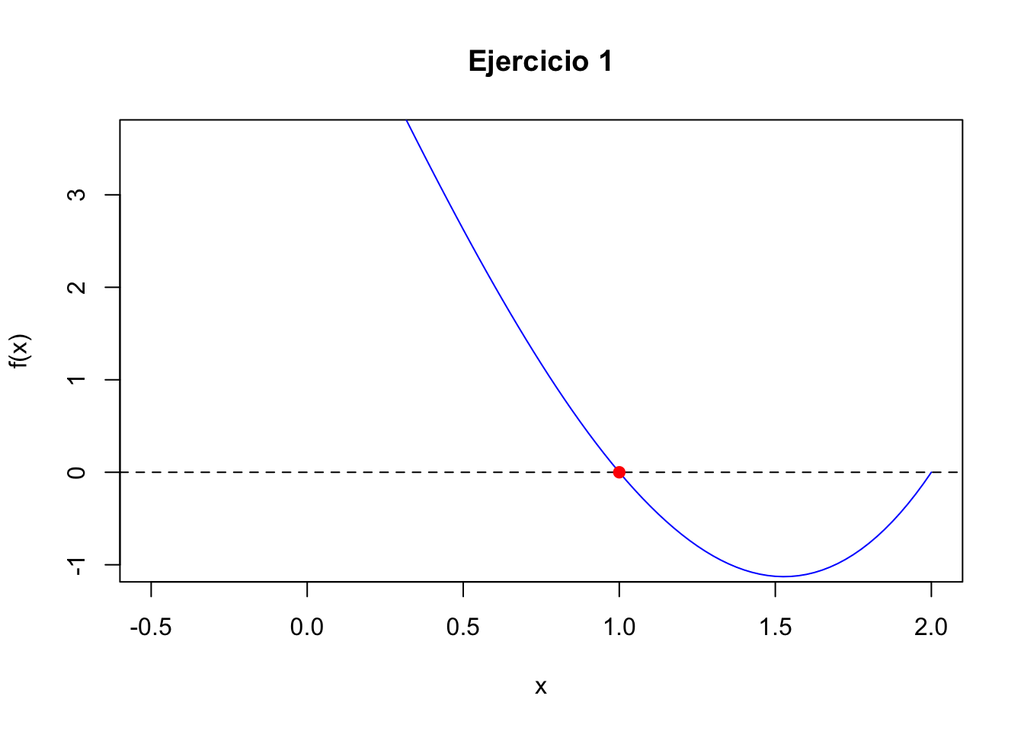

```
##
##
## Ejercicio 2
##   k       xk         f_xk     df_xk        error
## 1 1 1.500000 2.875000e+00 12.750000 2.254902e-01
## 2 2 1.274510 3.190326e-01  9.971165 3.199552e-02
## 3 3 1.242514 5.928872e-03  9.601582 6.174890e-04
## 4 4 1.241897 2.183635e-06  9.594510 2.275921e-07
```

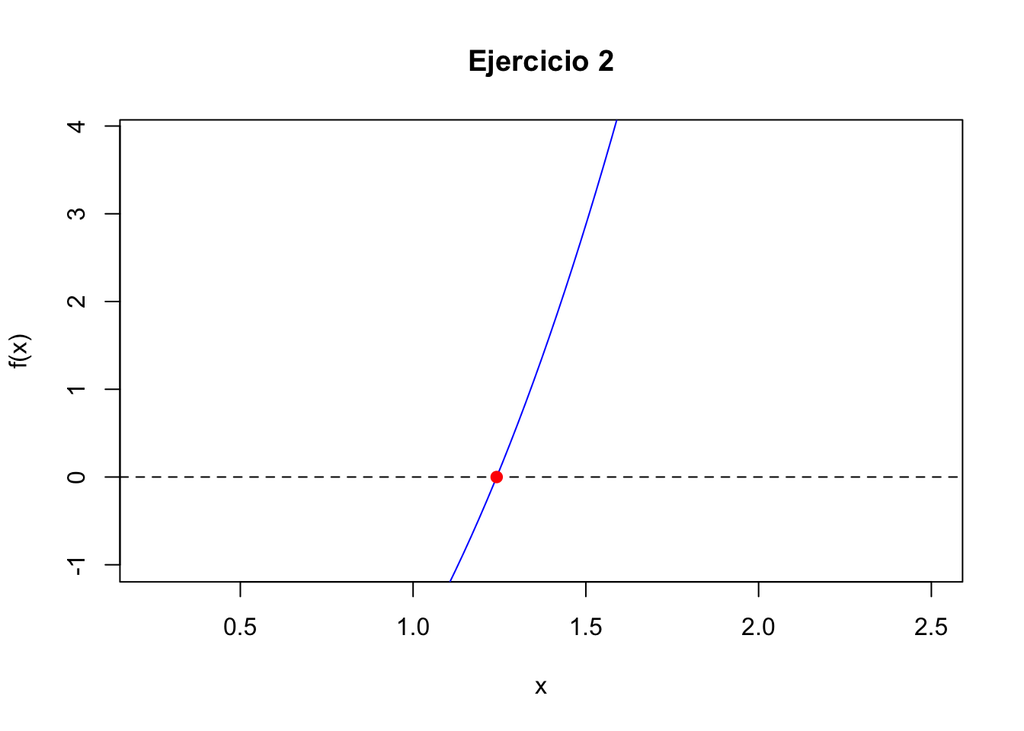

```
##
##
## Ejercicio 3
##   k       xk          f_xk     df_xk        error
## 1 1 0.500000  1.687500e+00 -1.750000 9.642857e-01
## 2 2 1.464286 -2.821564e+00 -6.738703 4.187102e-01
## 3 3 1.045576 -2.340099e-01 -5.266843 4.443077e-02
## 4 4 1.001145 -5.727571e-03 -5.006864 1.143944e-03
## 5 5 1.000001 -3.922819e-06 -5.000005 7.845630e-07
```

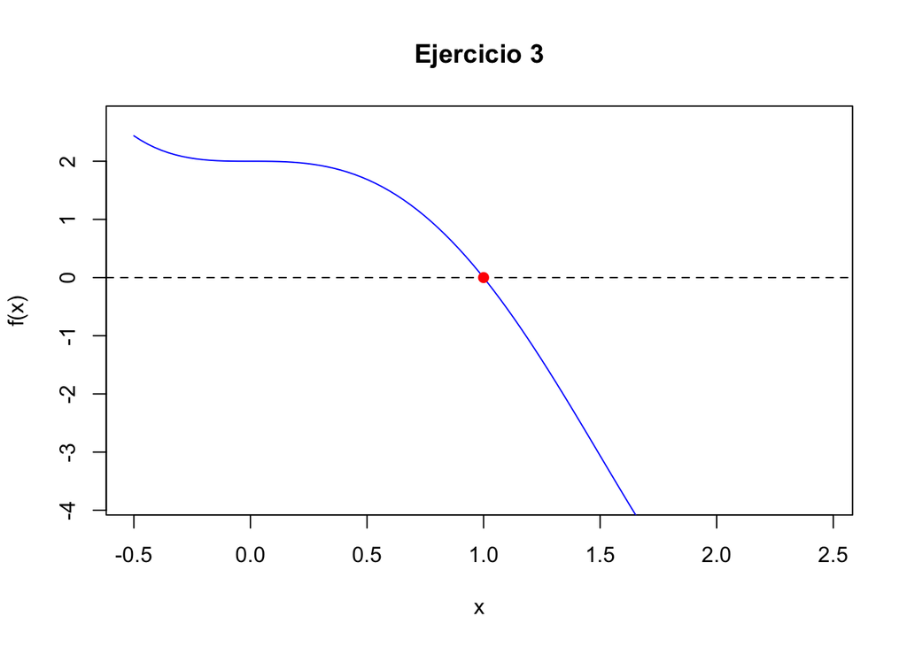

```
##
##
## Ejercicio 4
##   k       xk          f_xk      df_xk        error
## 1 1 1.000000  5.081377e-01 -0.4596977 1.105374e+00
## 2 2 2.105374 -2.250274e+00 -4.9420748 4.553298e-01
## 3 3 1.650044 -5.006326e-01 -2.8018089 1.786819e-01
## 4 4 1.471362 -6.672608e-02 -2.0656350 3.230294e-02
## 5 5 1.439059 -2.042660e-03 -1.9395338 1.053171e-03
## 6 6 1.438006 -2.145523e-06 -1.9354598 1.108534e-06
```

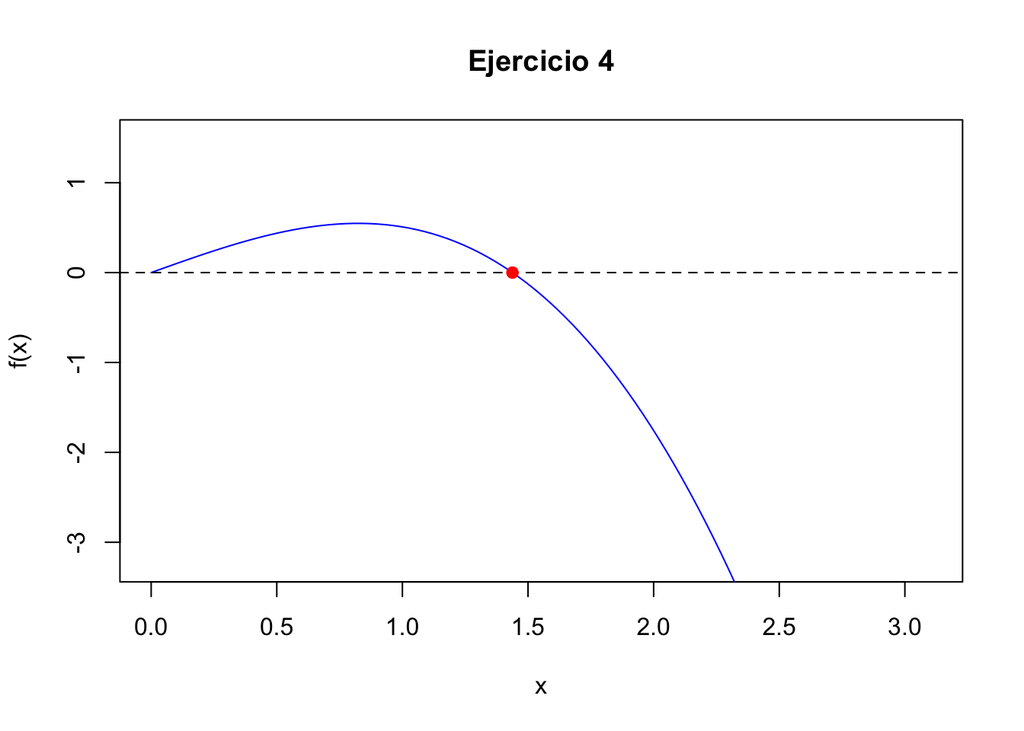

```
##
##
## Ejercicio 5
##   k        xk         f_xk     df_xk        error
## 1 1 0.5000000 1.065307e-01 -1.606531 6.631100e-02
## 2 2 0.5663110 1.304510e-03 -1.567616 8.321618e-04
## 3 3 0.5671432 1.964805e-07 -1.567143 1.253749e-07
```

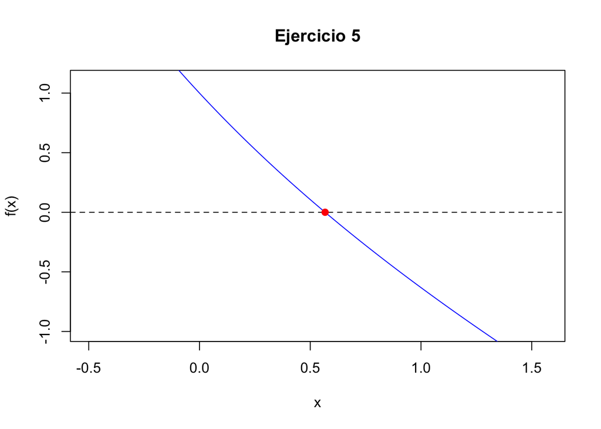

```
##
##
## Ejercicio 6
##   k       xk         f_xk    df_xk        error
## 1 1 2.500000 5.625000e+00 16.75000 3.358209e-01
## 2 2 2.164179 8.079451e-01 12.05101 6.704375e-02
## 3 3 2.097135 2.888172e-02 11.19393 2.580123e-03
## 4 4 2.094555 4.186495e-05 11.16148 3.750840e-06
```

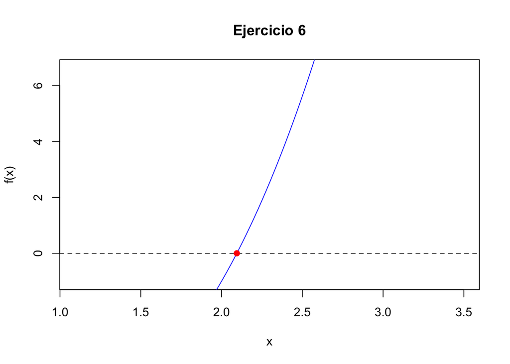

```
##
##
## Ejercicio 7
##   k        xk          f_xk     df_xk        error
## 1 1 0.5000000 -4.687500e-01 -2.687500 1.744186e-01
## 2 2 0.3255814  2.691427e-02 -2.943817 9.142645e-03
## 3 3 0.3347240  2.966998e-05 -2.937235 1.010133e-05
## 4 4 0.3347341  3.826750e-11 -2.937227 1.302847e-11
```

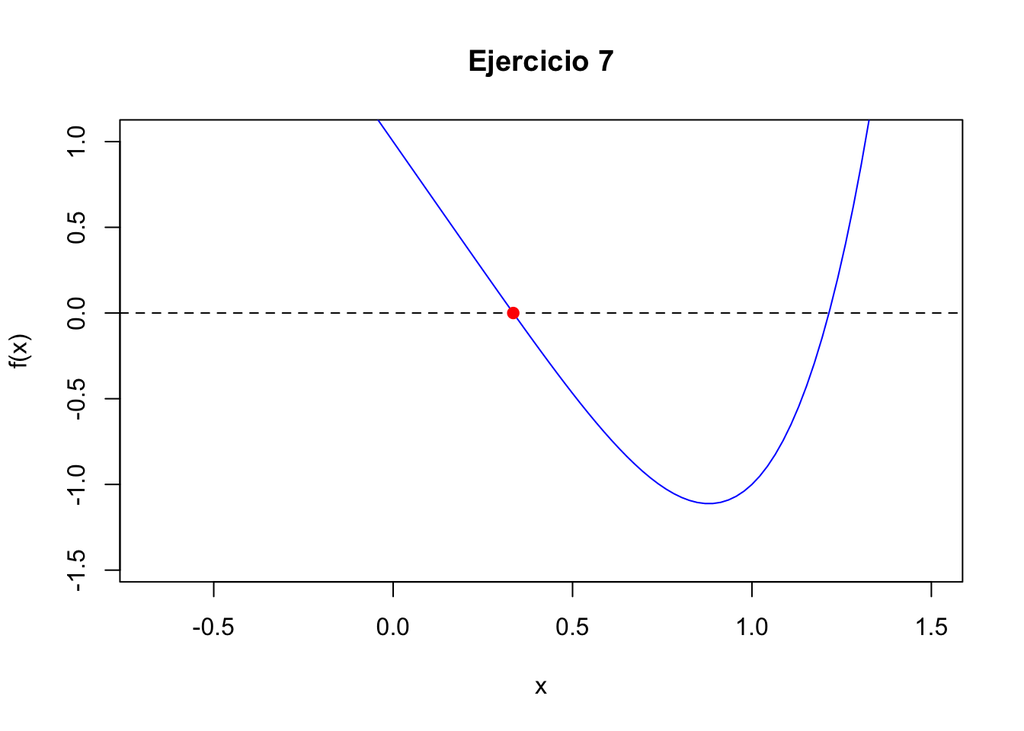

```
##
##
## Ejercicio 8
##   k        xk          f_xk     df_xk        error
## 1 1 0.5000000 -1.224174e-01 -2.479426 4.937331e-02
## 2 2 0.4506267 -1.079050e-03 -2.435530 4.430455e-04
## 3 3 0.4501836 -8.835361e-08 -2.435131 3.628290e-08
```

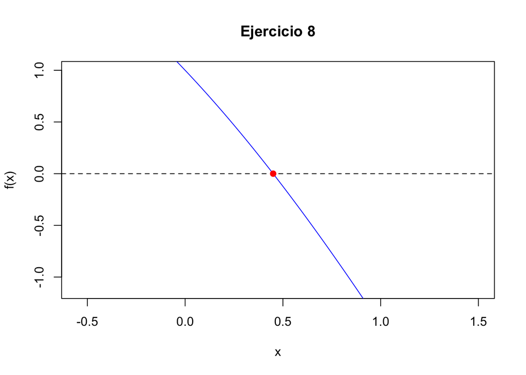

```
##
##
## Ejercicio 9
##   k         xk          f_xk    df_xk        error
## 1 1 -0.5000000 -1.094535e+00 1.666667 6.567209e-01
## 2 2  0.1567209 -7.469008e-02 1.463667 5.102943e-02
## 3 3  0.2077504 -2.755749e-04 1.452950 1.896658e-04
## 4 4  0.2079400 -3.689974e-09 1.452911 2.539711e-09
```

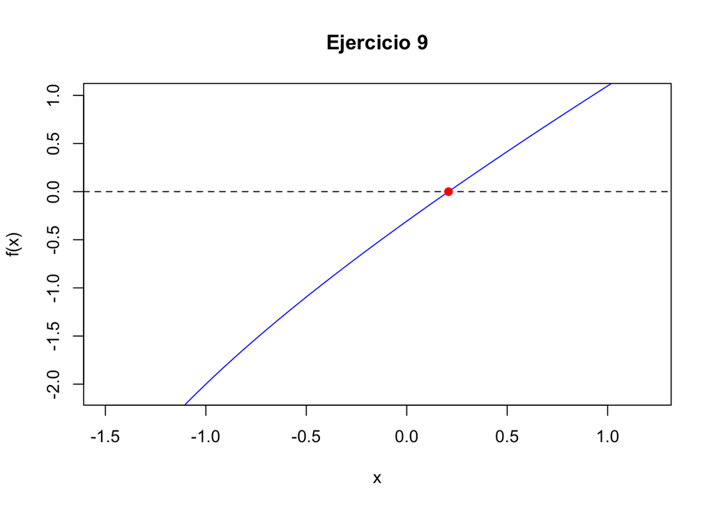

```
##
##
## Ejercicio 10
##   k         xk          f_xk     df_xk        error
## 1 1  0.5000000  2.032653e-01 0.3032653 6.702557e-01
## 2 2 -0.1702557 -3.018566e-01 1.3874646 2.175598e-01
## 3 3  0.0473041 -5.488148e-02 0.9086788 6.039701e-02
## 4 4  0.1077011 -3.295616e-03 0.8011915 4.113394e-03
## 5 5  0.1118145 -1.434420e-05 0.7942245 1.806064e-05
## 6 6  0.1118326 -2.753700e-10 0.7941940 3.467289e-10
```

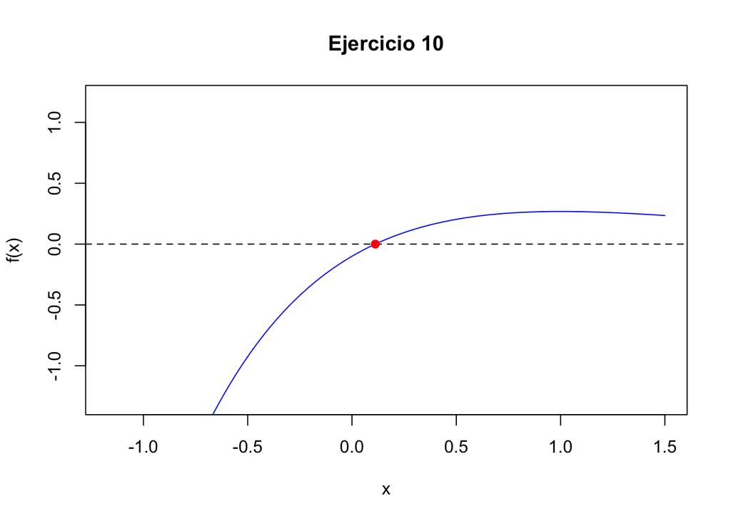

```
##
##
## Ejercicio 11
##   k       xk          f_xk    df_xk        error
## 1 1 1.500000 -6.149799e-01 6.467051 9.509434e-02
## 2 2 1.595094  5.962063e-02 7.730160 7.712729e-03
## 3 3 1.587382  4.031436e-04 7.625679 5.286658e-05
## 4 4 1.587329  1.889844e-08 7.624964 2.478495e-09
```

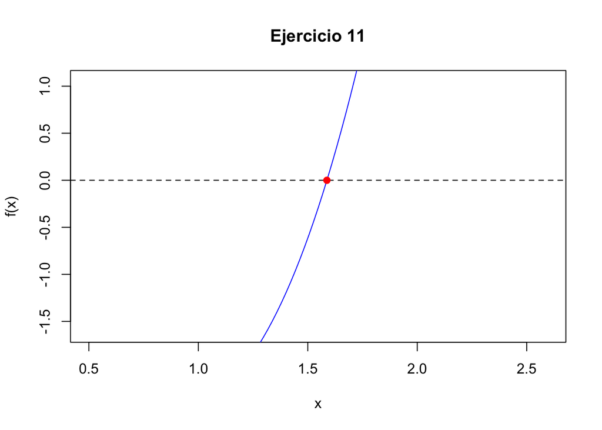

```
##
##
## Ejercicio 12
##   k        xk          f_xk     df_xk        error
## 1 1 0.5000000  8.987213e-01 -1.351279 6.650895e-01
## 2 2 1.1650895 -8.660907e-01 -3.784327 2.288625e-01
## 3 3 0.9362269 -7.922199e-02 -3.067021 2.583027e-02
## 4 4 0.9103967 -1.158090e-03 -2.977072 3.890030e-04
## 5 5 0.9100077 -2.659518e-07 -2.975704 8.937441e-08
```

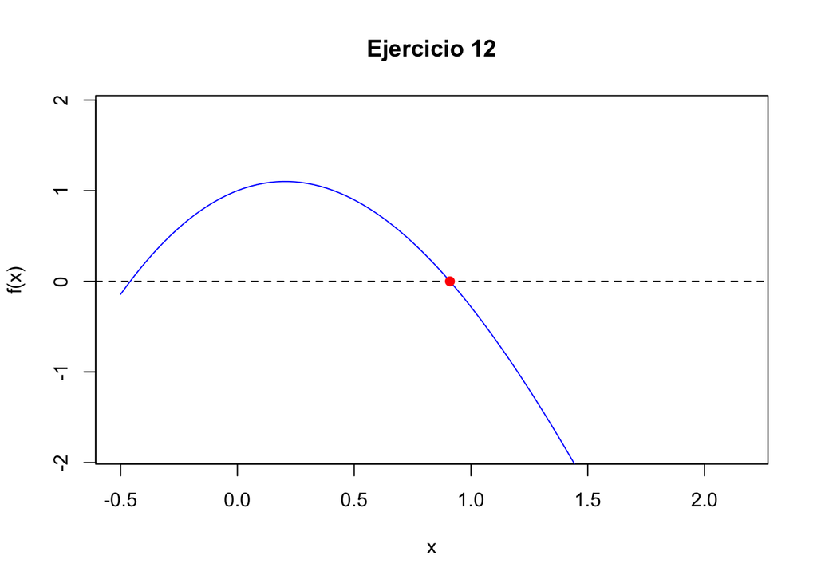

```
##
##
## Ejercicio 13
##   k        xk          f_xk    df_xk        error
## 1 1 0.5000000 -6.275826e-01 1.958851 3.203830e-01
## 2 2 0.8203830 -8.912889e-03 3.103580 2.871809e-03
## 3 3 0.8232548 -2.089405e-03 3.113234 6.711364e-04
## 4 4 0.8239259 -4.915827e-04 3.115489 1.577867e-04
## 5 5 0.8240837 -1.157535e-04 3.116019 3.714787e-05
## 6 6 0.8241209 -2.726193e-05 3.116144 8.748610e-06
```

[3 more figures not shown]

```r
# Método de Newton en R puro
newton <- function(f, df, x0, tol = 1e-5, max_iter = 10) {
  iter <- numeric()
  xk <- numeric()
  fxk <- numeric()
  dfxk <- numeric()
  error <- numeric()

  x <- x0

  for (k in 1:max_iter) {
    fx <- f(x)
    dfx <- df(x)
    x_new <- x - fx/dfx
    e <- abs(x_new - x)

    iter <- c(iter, k)
    xk <- c(xk, x)
    fxk <- c(fxk, fx)
    dfxk <- c(dfxk, dfx)
    error <- c(error, e)

    x <- x_new

    if (e < tol && k >= 1) break
  }

  resultados <- data.frame(
    k = iter,
    xk = xk,
    f_xk = fxk,
    df_xk = dfxk,
    error = error
  )

  return(resultados)
}

# Función para graficar y marcar la raíz
graficar_newton <- function(f, tabla, titulo = "Método de Newton") {
  plot(NULL, xlim = c(min(tabla$xk)-1, max(tabla$xk)+1),
       ylim = c(min(tabla$f_xk)-1, max(tabla$f_xk)+1),
       xlab = "x", ylab = "f(x)", main = titulo)
  curve(f(x), from = min(tabla$xk)-1, to = max(tabla$xk)+1, add = TRUE, col = "blue")
  abline(h = 0, col = "black", lty = 2)
  points(tabla$xk[nrow(tabla)], 0, col = "red", pch = 19) # raíz aproximada
}

# Lista de funciones y derivadas para los 15 ejercicios
funciones <- list(
  function(x) x^3 - 7*x + 6,          function(x) x^3 + 2*x^2 - 5,
  function(x) x^4 - 3*x^3 + 2,        function(x) sin(x) - x^3/3,
  function(x) exp(-x) - x,             function(x) x^3 - 2*x - 5,
  function(x) x^5 - 3*x + 1,           function(x) cos(x) - 2*x,
  function(x) log(x+2) + x - 1,        function(x) x*exp(-x) - 0.1,
  function(x) x^3 - 4*sin(x),          function(x) exp(x) - 3*x^2,
  function(x) x^2 - cos(x),            function(x) x^3 + 4*x^2 - 10,
  function(x) 2*x*sin(x) - 1
)

derivadas <- list(
  function(x) 3*x^2 - 7,               function(x) 3*x^2 + 4*x,
  function(x) 4*x^3 - 9*x^2,           function(x) cos(x) - x^2,
  function(x) -exp(-x) - 1,            function(x) 3*x^2 - 2,
  function(x) 5*x^4 - 3,               function(x) -sin(x) - 2,
  function(x) 1/(x+2) + 1,             function(x) exp(-x) - x*exp(-x),
  function(x) 3*x^2 - 4*cos(x),        function(x) exp(x) - 6*x,
  function(x) 2*x + 2*sin(x),          function(x) 3*x^2 + 8*x,
  function(x) 2*sin(x) + 2*x*cos(x)
)

valores_iniciales <- c(0.5, 1.5, 0.5, 1, 0.5, 2.5, 0.5, 0.5, -0.5, 0.5, 1.5, 0.5, 0.5, 1.5, 0.5)

# Ejecutar Newton para los 15 ejercicios y graficar
resultados_newton <- list()

for (i in 1:15) {
  cat("\n\nEjercicio", i, "\n")
  res <- newton(funciones[[i]], derivadas[[i]], valores_iniciales[i], tol = 1e-5, max_iter = 10)
  print(res)
  resultados_newton[[i]] <- res
  graficar_newton(funciones[[i]], res, paste("Ejercicio", i))
}
```

## Método del Punto fijo

```r
punto_fijo <- function(g, x0, tol = 1e-5, max_iter = 10) {
  iter <- numeric()
  xk <- numeric()
  gxk <- numeric()
  error <- numeric()

  x <- x0
  for (k in 1:max_iter) {
    x_new <- tryCatch(g(x), error = function(e) NA)

    # Verificar que x_new sea válido
    if (is.na(x_new) || is.nan(x_new) || Im(x_new) != 0) {
      warning(paste("Iteración", k, "produjo valor inválido. Se detiene."))
      break
    }

    e <- abs(x_new - x)

    iter <- c(iter, k)
    xk <- c(xk, x)
    gxk <- c(gxk, x_new)
    error <- c(error, e)

    x <- x_new
    if (e < tol && k >= 1) break
  }

  resultados <- data.frame(
    k = iter,
    xk = xk,
    g_xk = gxk,
    error = error
  )

  return(resultados)
}
```

Función para graficar

```r
graficar_punto_fijo <- function(g, tabla, titulo = "Método del Punto Fijo") {
  if (nrow(tabla) == 0 || all(is.na(tabla$xk))) {
    warning("No hay datos válidos para graficar.")
    return()
  }

  x_vals <- tabla$xk[!is.na(tabla$xk)]
  g_vals <- tabla$g_xk[!is.na(tabla$g_xk)]

  # Crear rango de x para graficar
  x_range <- seq(min(x_vals) - 1, max(x_vals) + 1, length.out = 500)
  y_vals <- sapply(x_range, function(x) {
    y <- tryCatch(g(x), error = function(e) NA)
    if (!is.finite(y)) NA else y
  })

  plot(NULL, xlim = c(min(x_range), max(x_range)),
       ylim = c(min(y_vals, na.rm = TRUE), max(y_vals, na.rm = TRUE)),
       xlab = "x", ylab = "y", main = titulo)

  lines(x_range, y_vals, col = "blue")
  abline(0, 1, col = "red") # línea y=x

  # Punto de intersección final
  points(tail(g_vals, 1), tail(g_vals, 1), col = "green", pch = 19)
}
```

Funciones g(x) y valores iniciales

```r
g_funciones <- list(
  function(x) cos(x),                     # 1
  function(x) 1 - x^3,                    # 2
  function(x) exp(-x),                     # 3
  function(x) (x^2 + 1)/4,                 # 4
  function(x) (2*x + 5)^(1/3),             # 5
  function(x) sqrt(pmax(exp(x) - 2, 0)),   # 6, protege sqrt
  function(x) 2 - log(x + 1),              # 7
  function(x) (3*x - 1)^(1/3),             # 8
  function(x) sin(x) + 1,                  # 9
  function(x) sqrt(3),                     # 10
  function(x) exp(-x)/2,                   # 11
  function(x) (10 - x^3)/4,                # 12
  function(x) cos(x),                      # 13
  function(x) exp(-x^2),                   # 14
  function(x) 2^(1/3)                      # 15
)

valores_iniciales <- c(0.5, 0.6, 0.7, 1, 2, 0.5, 0.5, 0.8, 1, 1.5, 0.5, 1.5, 0.5, 0.5, 1)


resultados_punto_fijo <- list()

for (i in 1:15) {
  cat("\n\nEjercicio", i, "\n")
  res <- punto_fijo(g_funciones[[i]], valores_iniciales[i], tol = 1e-5, max_iter = 10)
  print(res)
  resultados_punto_fijo[[i]] <- res
  graficar_punto_fijo(g_funciones[[i]], res, paste("Ejercicio", i))
}
```

```
##
##
## Ejercicio 1
##     k        xk      g_xk      error
## 1   1 0.5000000 0.8775826 0.37758256
## 2   2 0.8775826 0.6390125 0.23857007
## 3   3 0.6390125 0.8026851 0.16367261
## 4   4 0.8026851 0.6947780 0.10790707
## 5   5 0.6947780 0.7681958 0.07341780
## 6   6 0.7681958 0.7191654 0.04903039
## 7   7 0.7191654 0.7523558 0.03319031
## 8   8 0.7523558 0.7300811 0.02227470
## 9   9 0.7300811 0.7451203 0.01503928
## 10 10 0.7451203 0.7350063 0.01011403
```

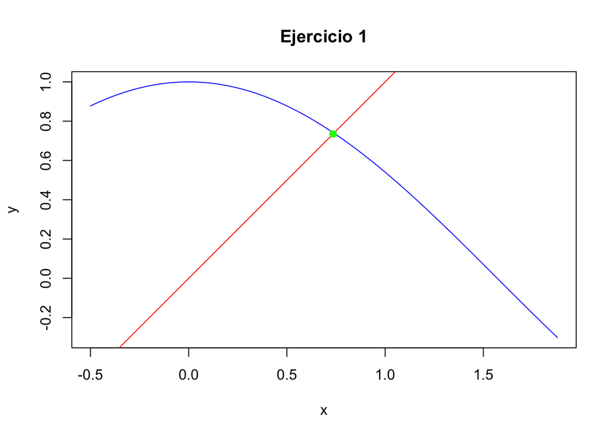

```
##
##
## Ejercicio 2
##     k          xk         g_xk     error
## 1   1 0.600000000 7.840000e-01 0.1840000
## 2   2 0.784000000 5.181097e-01 0.2658903
## 3   3 0.518109696 8.609198e-01 0.3428102
## 4   4 0.860919847 3.619009e-01 0.4990190
## 5   5 0.361900860 9.526010e-01 0.5907002
## 6   6 0.952601037 1.355634e-01 0.8170376
## 7   7 0.135563394 9.975087e-01 0.8619453
## 8   8 0.997508693 7.455318e-03 0.9900534
## 9   9 0.007455318 9.999996e-01 0.9925443
## 10 10 0.999999586 1.243139e-06 0.9999983
```

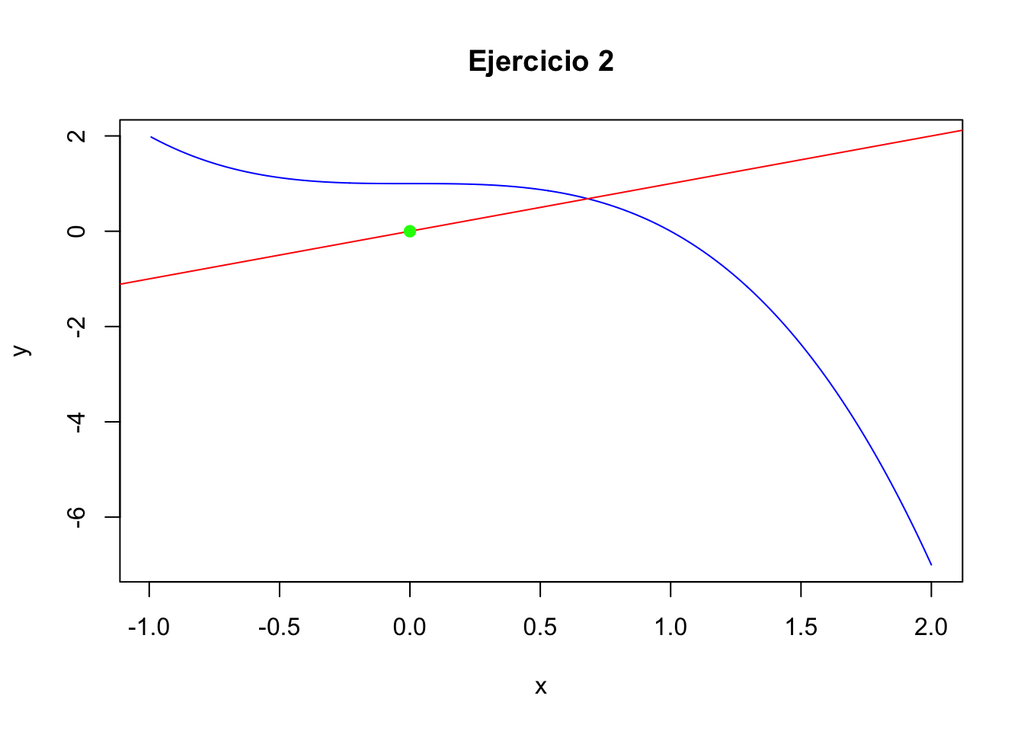

```
##
##
## Ejercicio 3
##     k        xk      g_xk       error
## 1   1 0.7000000 0.4965853 0.203414696
## 2   2 0.4965853 0.6086053 0.112020014
## 3   3 0.6086053 0.5441092 0.064496118
## 4   4 0.5441092 0.5803585 0.036249337
## 5   5 0.5803585 0.5596977 0.020660878
## 6   6 0.5596977 0.5713818 0.011684132
## 7   7 0.5713818 0.5647445 0.006637249
## 8   8 0.5647445 0.5685054 0.003760817
## 9   9 0.5685054 0.5663713 0.002134029
## 10 10 0.5663713 0.5675813 0.001209944
```

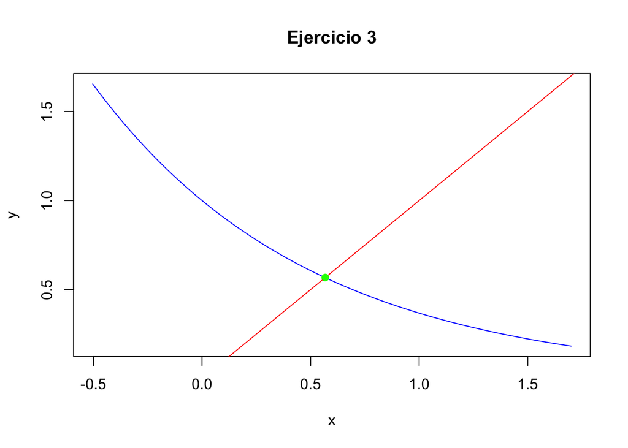

```
##
##
## Ejercicio 4
##   k        xk      g_xk        error
## 1 1 1.0000000 0.5000000 5.000000e-01
## 2 2 0.5000000 0.3125000 1.875000e-01
## 3 3 0.3125000 0.2744141 3.808594e-02
## 4 4 0.2744141 0.2688258 5.588293e-03
## 5 5 0.2688258 0.2680668 7.589458e-04
## 6 6 0.2680668 0.2679650 1.018681e-04
## 7 7 0.2679650 0.2679513 1.365113e-05
## 8 8 0.2679513 0.2679495 1.828966e-06
```

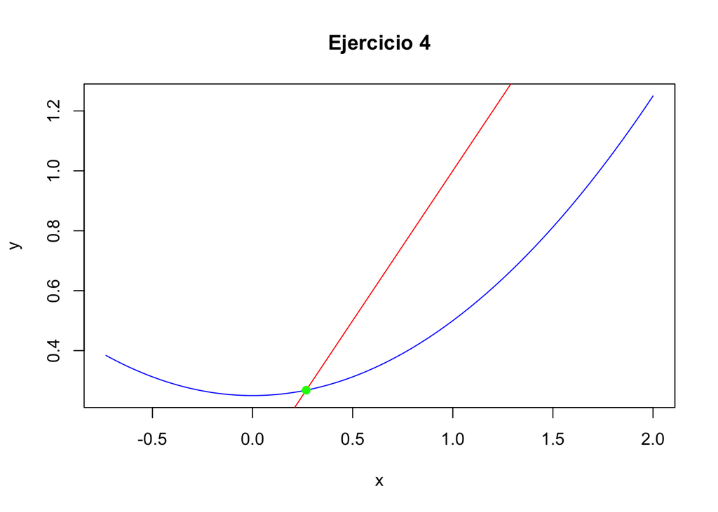

```
##
##
## Ejercicio 5
##   k       xk     g_xk        error
## 1 1 2.000000 2.080084 8.008382e-02
## 2 2 2.080084 2.092351 1.226685e-02
## 3 3 2.092351 2.094217 1.866318e-03
## 4 4 2.094217 2.094501 2.836562e-04
## 5 5 2.094501 2.094544 4.310534e-05
## 6 6 2.094544 2.094550 6.550275e-06
```

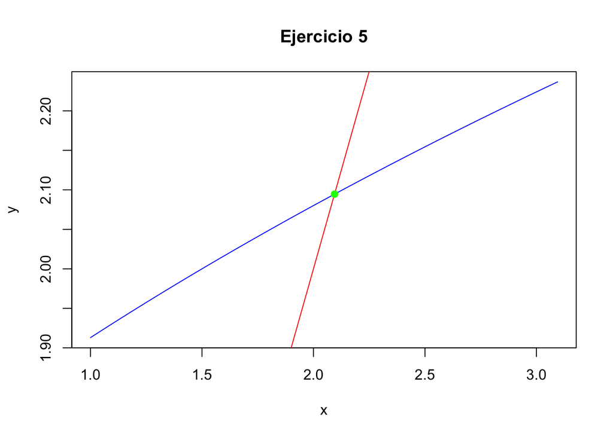

```
##
##
## Ejercicio 6
##   k  xk g_xk error
## 1 1 0.5    0   0.5
## 2 2 0.0    0   0.0
```

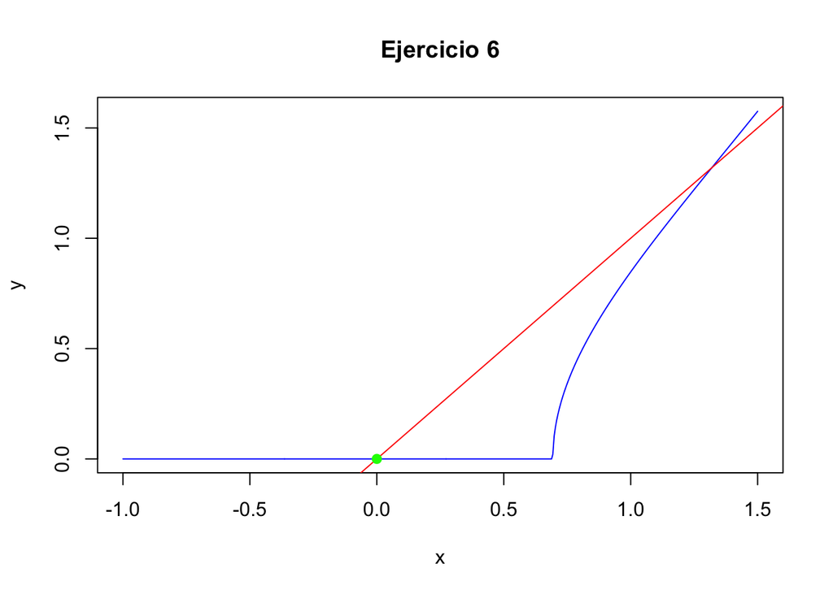

```
##
##
## Ejercicio 7
##     k       xk     g_xk        error
## 1   1 0.500000 1.594535 1.0945348919
## 2   2 1.594535 1.046593 0.5479421600
## 3   3 1.046593 1.283824 0.2372309398
## 4   4 1.283824 1.174149 0.1096747589
## 5   5 1.174149 1.223363 0.0492138038
## 6   6 1.223363 1.200979 0.0223835035
## 7   7 1.200979 1.211098 0.0101184288
## 8   8 1.211098 1.206511 0.0045867046
## 9   9 1.206511 1.208587 0.0020765562
## 10 10 1.208587 1.207647 0.0009406614
```

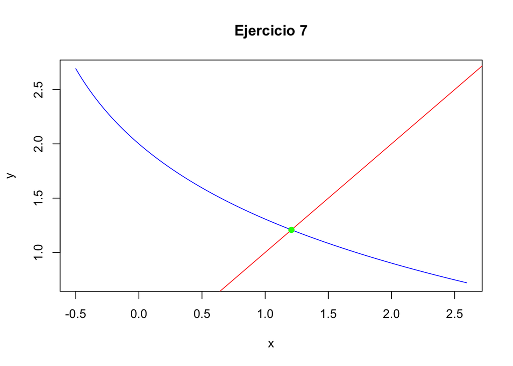

```
##
##
## Ejercicio 8
##     k       xk     g_xk        error
## 1   1 0.800000 1.118689 0.3186889421
## 2   2 1.118689 1.330646 0.2119570641
## 3   3 1.330646 1.440956 0.1103104730
## 4   4 1.440956 1.492237 0.0512803662
## 5   5 1.492237 1.514919 0.0226824990
## 6   6 1.514919 1.524739 0.0098197361
## 7   7 1.524739 1.528951 0.0042122053
## 8   8 1.528951 1.530751 0.0017997456
## 9   9 1.530751 1.531519 0.0007676871
## 10 10 1.531519 1.531846 0.0003272253
```

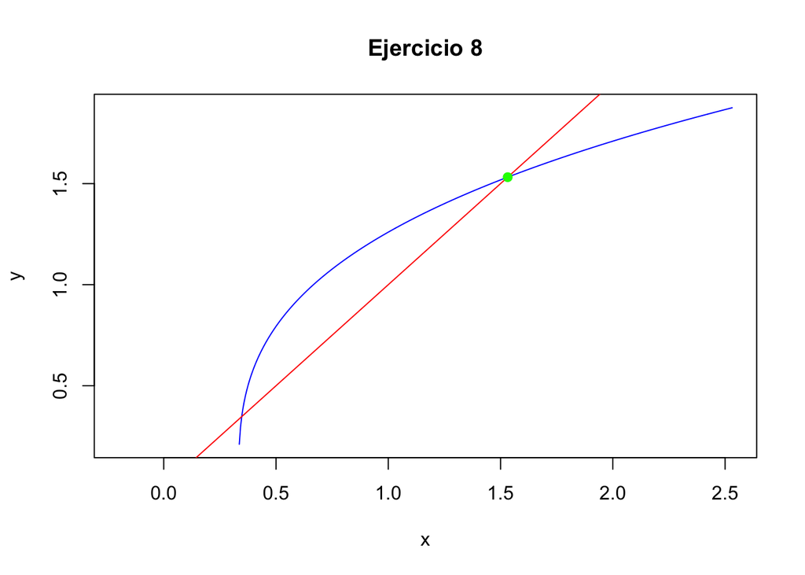

```
##
##
## Ejercicio 9
##     k       xk     g_xk        error
## 1   1 1.000000 1.841471 8.414710e-01
## 2   2 1.841471 1.963591 1.221197e-01
## 3   3 1.963591 1.923843 3.974767e-02
## 4   4 1.923843 1.938324 1.448059e-02
## 5   5 1.938324 1.933219 5.104983e-03
## 6   6 1.933219 1.935041 1.822098e-03
## 7   7 1.935041 1.934393 6.475589e-04
## 8   8 1.934393 1.934624 2.304926e-04
## 9   9 1.934624 1.934542 8.199682e-05
## 10 10 1.934542 1.934571 2.917573e-05
```

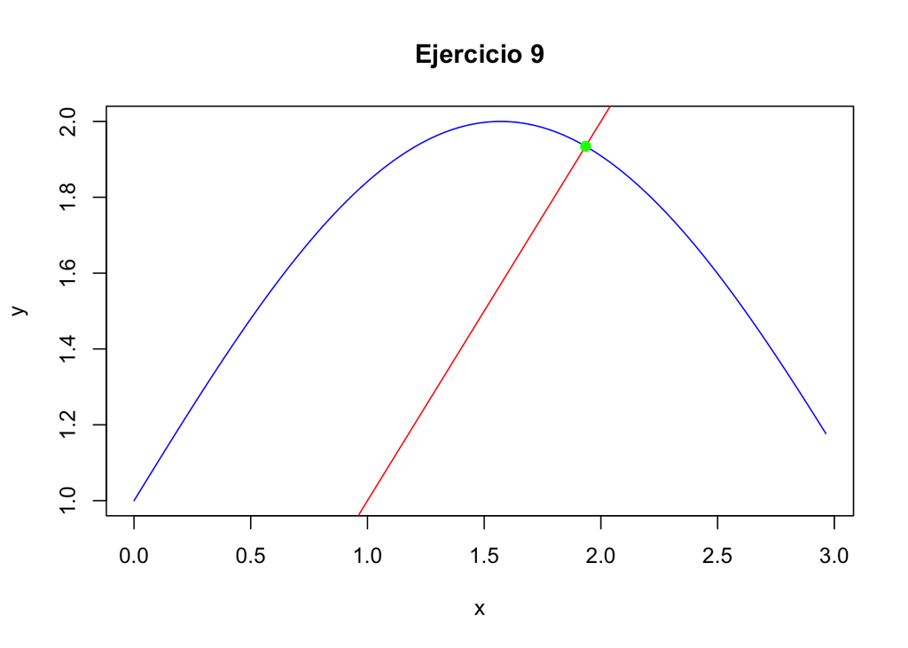

```
##
##
## Ejercicio 10
##   k       xk     g_xk     error
## 1 1 1.500000 1.732051 0.2320508
## 2 2 1.732051 1.732051 0.0000000
```

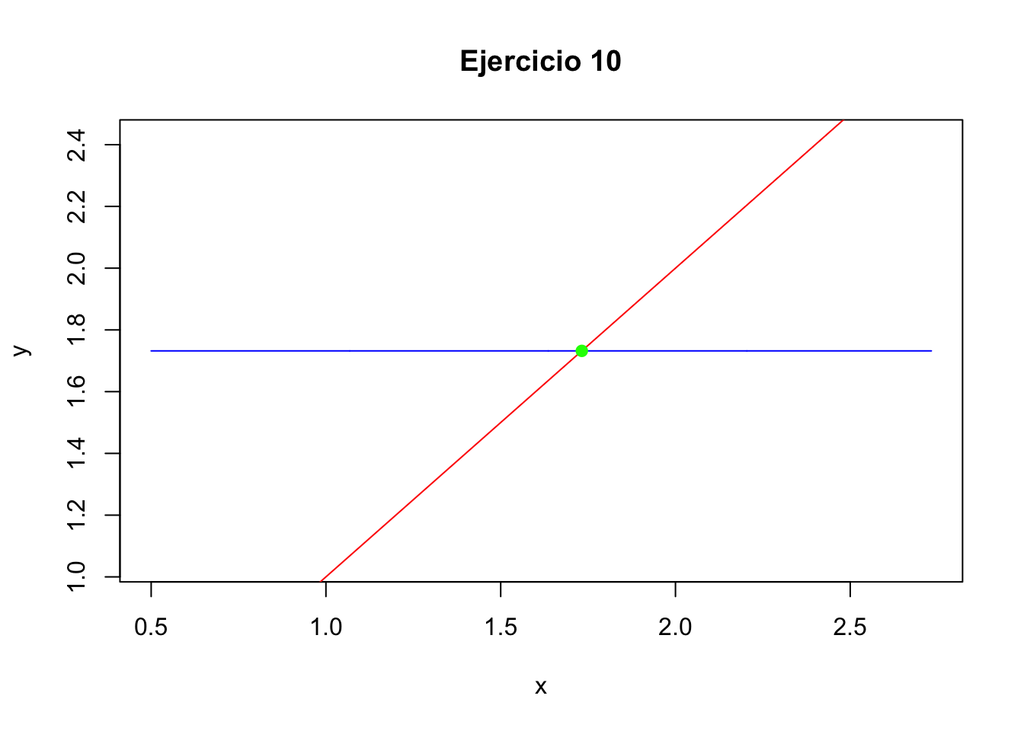

```
##
##
## Ejercicio 11
##     k        xk      g_xk        error
## 1   1 0.5000000 0.3032653 1.967347e-01
## 2   2 0.3032653 0.3692016 6.593625e-02
## 3   3 0.3692016 0.3456430 2.355855e-02
## 4   4 0.3456430 0.3538825 8.239523e-03
## 5   5 0.3538825 0.3509787 2.903844e-03
## 6   6 0.3509787 0.3519994 1.020669e-03
## 7   7 0.3519994 0.3516403 3.590914e-04
## 8   8 0.3516403 0.3517666 1.262937e-04
## 9   9 0.3517666 0.3517222 4.442309e-05
## 10 10 0.3517222 0.3517378 1.562493e-05
```

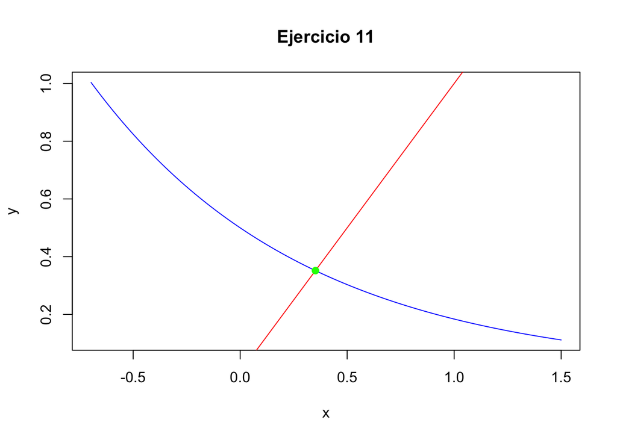

```
##
##
## Ejercicio 12
##     k         xk        g_xk      error
## 1   1  1.5000000   1.6562500  0.1562500
## 2   2  1.6562500   1.3641586  0.2920914
## 3   3  1.3641586   1.8653495  0.5011909
## 4   4  1.8653495   0.8773657  0.9879838
## 5   5  0.8773657   2.3311574  1.4537917
## 6   6  2.3311574  -0.6670492  2.9982066
## 7   7 -0.6670492   2.5742017  3.2412509
## 8   8  2.5742017  -1.7644960  4.3386976
## 9   9 -1.7644960   3.8734157  5.6379117
## 10 10  3.8734157 -12.0285523 15.9019680
```

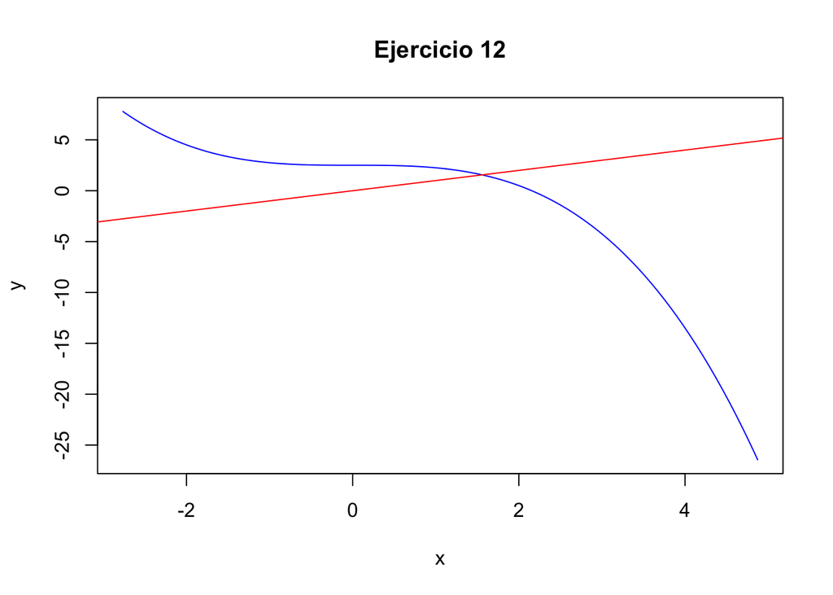

```
##
##
## Ejercicio 13
##     k        xk      g_xk      error
## 1   1 0.5000000 0.8775826 0.37758256
## 2   2 0.8775826 0.6390125 0.23857007
## 3   3 0.6390125 0.8026851 0.16367261
## 4   4 0.8026851 0.6947780 0.10790707
## 5   5 0.6947780 0.7681958 0.07341780
## 6   6 0.7681958 0.7191654 0.04903039
## 7   7 0.7191654 0.7523558 0.03319031
## 8   8 0.7523558 0.7300811 0.02227470
## 9   9 0.7300811 0.7451203 0.01503928
## 10 10 0.7451203 0.7350063 0.01011403
```

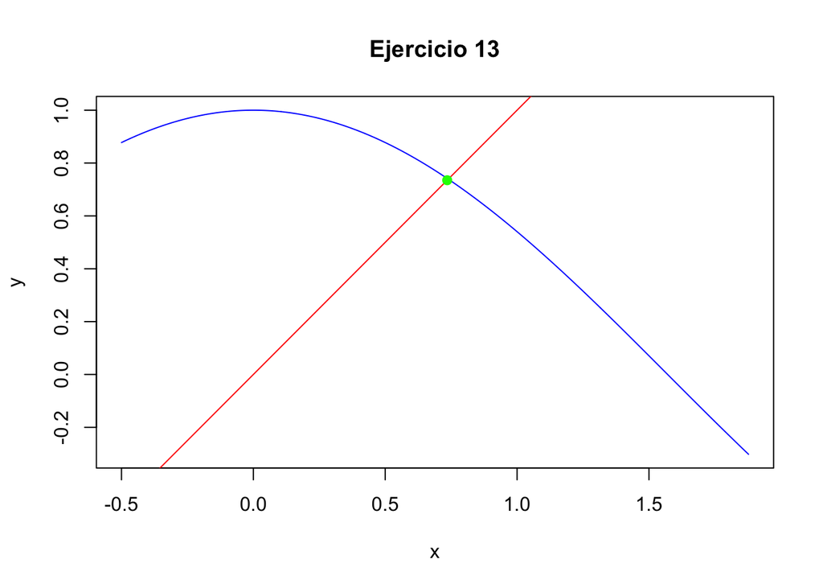

```
##
##
## Ejercicio 14
##     k        xk      g_xk      error
## 1   1 0.5000000 0.7788008 0.27880078
## 2   2 0.7788008 0.5452392 0.23356157
## 3   3 0.5452392 0.7428317 0.19759247
## 4   4 0.7428317 0.5759129 0.16691882
## 5   5 0.5759129 0.7177201 0.14180723
## 6   6 0.7177201 0.5974276 0.12029247
## 7   7 0.5974276 0.6998286 0.10240102
## 8   8 0.6998286 0.6127734 0.08705529
## 9   9 0.6127734 0.6869518 0.07417841
## 10 10 0.6869518 0.6238142 0.06313759
```

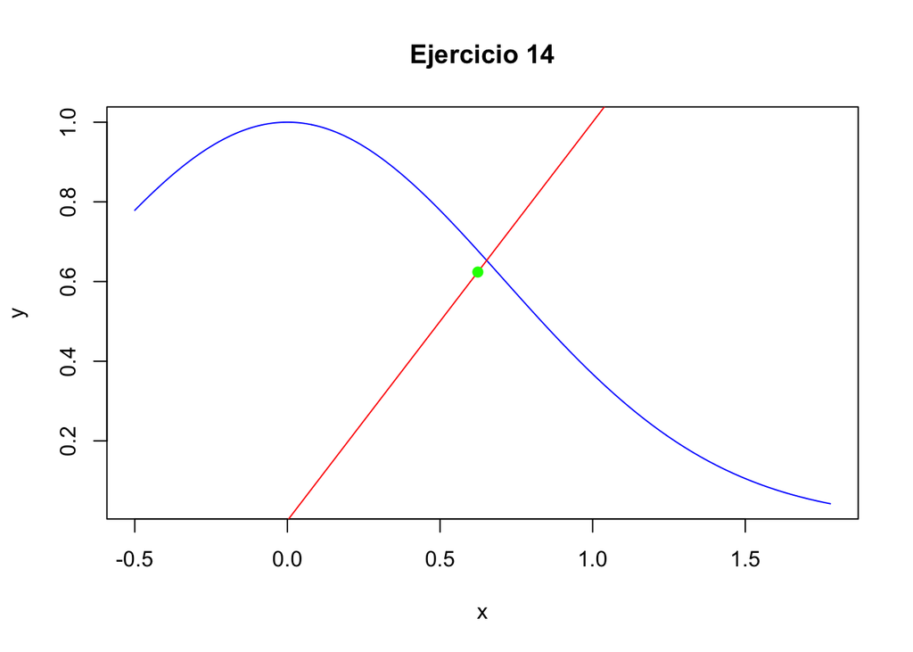

```
##
##
## Ejercicio 15
##   k       xk     g_xk    error
## 1 1 1.000000 1.259921 0.259921
## 2 2 1.259921 1.259921 0.000000
```

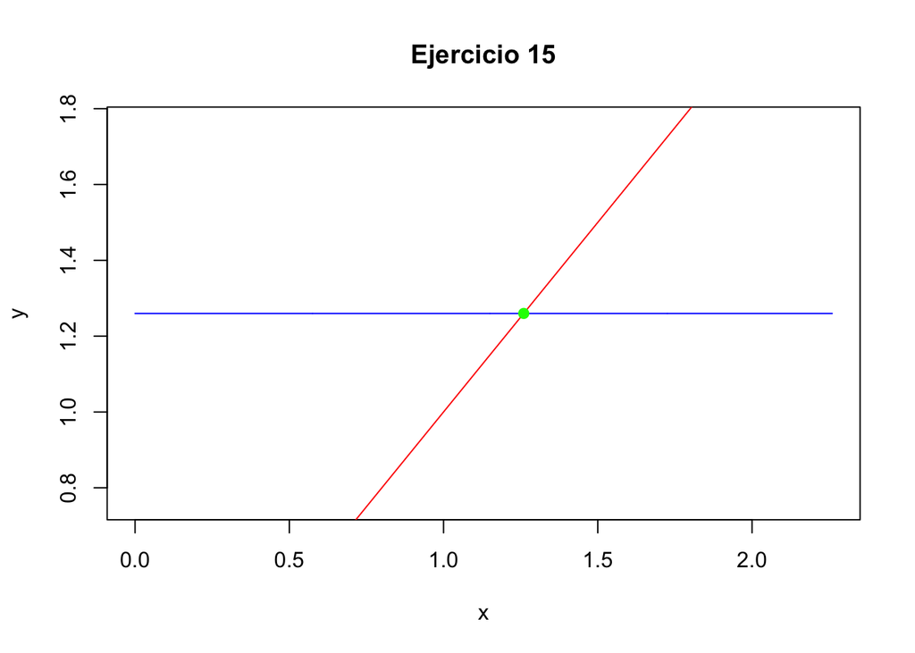

# Interpolación

## **Interpolación de Lagrange y Newton**

Este documento presenta los cálculos de interpolación para tres conjuntos de puntos, utilizando los métodos de **Lagrange** y **Newton (diferencias divididas)**.

#### **Ejercicio 5**

```r
## Datos dados

x <- c(0, 1, 2)
y <- c(1, 3, 11)

## Definimos función del polinomio de Lagrange
P_Lagrange <- function(xv) {
  L0 <- (xv - 1)*(xv - 2) / ((0 - 1)*(0 - 2))
  L1 <- (xv - 0)*(xv - 2) / ((1 - 0)*(1 - 2))
  L2 <- (xv - 0)*(xv - 1) / ((2 - 0)*(2 - 1))
  return(1*L0 + 3*L1 + 11*L2)
}

## Comprobamos el polinomio con varios puntos
xx <- seq(0, 2, by=0.5)
yy <- P_Lagrange(xx)

## Ajuste simbólico para obtener coeficientes del polinomio
fit <- lm(yy ~ poly(xx, 2, raw=TRUE))
coeficientes <- coef(fit)
a0 <- round(coeficientes[1], 6)
a1 <- round(coeficientes[2], 6)
a2 <- round(coeficientes[3], 6)

cat("Polinomio interpolante por Lagrange:\n")
```

```
## Polinomio interpolante por Lagrange:
```

```r
cat("P(x) =", a2, "* x^2 +", a1, "* x +", a0, "\n\n")
```

```
## P(x) = 3 * x^2 + -1 * x + 1
```

#### b) Verificación con diferencias divididas (Newton)

```r
## Calculamos las diferencias divididas
f_x0 <- y[1]
f_x0x1 <- (y[2]-y[1])/(x[2]-x[1])
f_x1x2 <- (y[3]-y[2])/(x[3]-x[2])
f_x0x1x2 <- (f_x1x2 - f_x0x1)/(x[3]-x[1])

cat("Tabla de diferencias divididas:\n")
```

```
## Tabla de diferencias divididas:
```

```r
cat("f[x0] =", f_x0, "\n")
```

```
## f[x0] = 1
```

```r
cat("f[x0,x1] =", f_x0x1, "\n")
```

```
## f[x0,x1] = 2
```

```r
cat("f[x1,x2] =", f_x1x2, "\n")
```

```
## f[x1,x2] = 8
```

```r
cat("f[x0,x1,x2] =", f_x0x1x2, "\n\n")
```

```
## f[x0,x1,x2] = 3
```

```r
## Forma de Newton:
## P(x) = f[x0] + f[x0,x1]*(x - x0) + f[x0,x1,x2]*(x - x0)*(x - x1)
P_Newton <- function(xv) {
  f_x0 + f_x0x1*(xv - x[1]) + f_x0x1x2*(xv - x[1])*(xv - x[2])
}

## Comprobamos que ambos métodos coinciden
test_points <- seq(0,2,by=0.5)
cat("Comparación Lagrange vs Newton:\n")
```

```
## Comparación Lagrange vs Newton:
```

```r
for (i in seq_along(test_points)) {
  cat("x =", test_points[i],
      "Lagrange =", round(P_Lagrange(test_points[i]),4),
      "Newton =", round(P_Newton(test_points[i]),4), "\n")
}
```

```
## x = 0 Lagrange = 1 Newton = 1
## x = 0.5 Lagrange = 1.25 Newton = 1.25
## x = 1 Lagrange = 3 Newton = 3
## x = 1.5 Lagrange = 6.25 Newton = 6.25
## x = 2 Lagrange = 11 Newton = 11
```

#### c) Evaluación del polinomio en x = 1.5

```r
x_eval <- 1.5
P_val <- 3*x_eval^2 - x_eval + 1
cat("\nEvaluación en x = 1.5:\n")
```

```
##
## Evaluación en x = 1.5:
```

```r
cat("P(1.5) =", P_val, "\n\n")
```

```
## P(1.5) = 6.25
```

```r
cat("Conclusión: el polinomio 3x² - x + 1 coincide en ambos métodos.\n")
```

```
## Conclusión: el polinomio 3x² - x + 1 coincide en ambos métodos.
```

```r
cat("El valor en x=1.5 es 6.25, igual al obtenido por ajuste visual cuadrático.\n")
```

```
## El valor en x=1.5 es 6.25, igual al obtenido por ajuste visual cuadrático.
```

## d) Gráfico del polinomio y los puntos

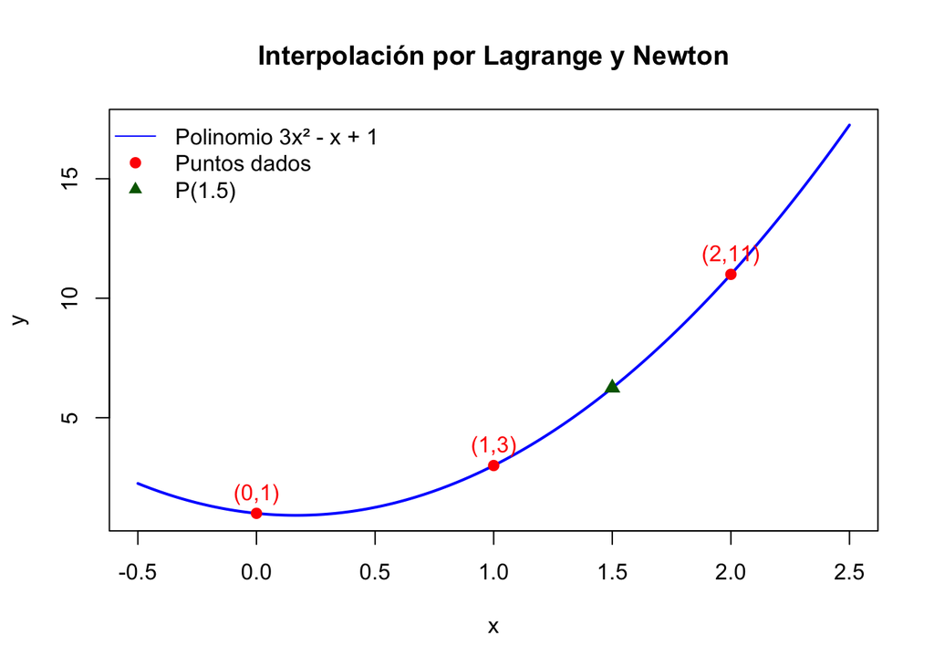

```r
xs_plot <- seq(min(x)-0.5, max(x)+0.5, length.out=200)
ys_plot <- 3*xs_plot^2 - xs_plot + 1

plot(xs_plot, ys_plot, type="l", lwd=2, col="blue",
     xlab="x", ylab="y", main="Interpolación por Lagrange y Newton")
points(x, y, pch=19, col="red")
text(x, y, labels=paste0("(",x,",",y,")"), pos=3, col="red")
points(x_eval, P_val, pch=17, col="darkgreen", cex=1.2)
legend("topleft", legend=c("Polinomio 3x² - x + 1", "Puntos dados", "P(1.5)"),
       col=c("blue","red","darkgreen"), pch=c(NA,19,17), lty=c(1,NA,NA), bty="n")
```

#### **Ejercicio 5.1**

```r
## Datos

x <- c(1,2,3,4)
y <- c(2,5,10,17)
```

## a) Polinomio interpolante por Newton

```r
n <- length(x)
dd <- matrix(NA, nrow=n, ncol=n)
dd[,1] <- y
for (j in 2:n) {
  for (i in 1:(n-j+1)) {
    dd[i,j] <- (dd[i+1,j-1] - dd[i,j-1]) / (x[i+j-1] - x[i])
  }
}
coef_newton <- dd[1,]
```

## b) Tabla de diferencias divididas

```r
dd_print <- dd
dd_print[is.na(dd_print)] <- ""
cat("**Tabla de diferencias divididas (Newton):**\n\n")
```

```
## **Tabla de diferencias divididas (Newton):**
```

```r
print(knitr::kable(dd_print, digits=6, col.names=paste0("Orden ",0:(n-1))))
```

```
##
##
## |Orden 0 |Orden 1 |Orden 2 |Orden 3 |
## |:-------|:-------|:-------|:-------|
## |2       |3       |1       |0       |
## |5       |5       |1       |        |
## |10      |7       |        |        |
## |17      |        |        |        |
```

```r
## Forma de Newton

P_newton_eval <- function(xv) {
  s <- coef_newton[1]
  term <- 1
  for (k in 2:length(coef_newton)) {
    term <- term * (xv - x[k-1])
    s <- s + coef_newton[k]*term
  }
  return(s)
}
```

## c) Evaluar en x = 2.5

```r
x_eval <- 2.5
P_at_2_5 <- P_newton_eval(x_eval)
cat("\n**Evaluación del polinomio en x = 2.5:**\n")
```

```
##
## **Evaluación del polinomio en x = 2.5:**
```

```r
cat("P(2.5) =", round(P_at_2_5, 6), "\n")
```

```
## P(2.5) = 7.25
```

## d) Comparar con f(x) = x² + 1

```r
f_direct <- function(xv) xv^2 + 1
f_at_2_5 <- f_direct(x_eval)
cat("\n**Comparación con f(x) = x² + 1:**\n")
```

```
##
## **Comparación con f(x) = x² + 1:**
```

```r
cat("f(2.5) =", round(f_at_2_5, 6), "\n")
```

```
## f(2.5) = 7.25
```

```r
cat("Diferencia =", round(P_at_2_5 - f_at_2_5, 12), "\n")
```

```
## Diferencia = 0
```

```r
if (abs(P_at_2_5 - f_at_2_5) < 1e-10) {
  cat("\n El polinomio interpolante coincide con f(x)=x²+1.\n")
} else {
  cat("\n Hay una pequeña diferencia numérica.\n")
}
```

```
##
##  El polinomio interpolante coincide con f(x)=x²+1.
```

## e) Gráfica comparativa

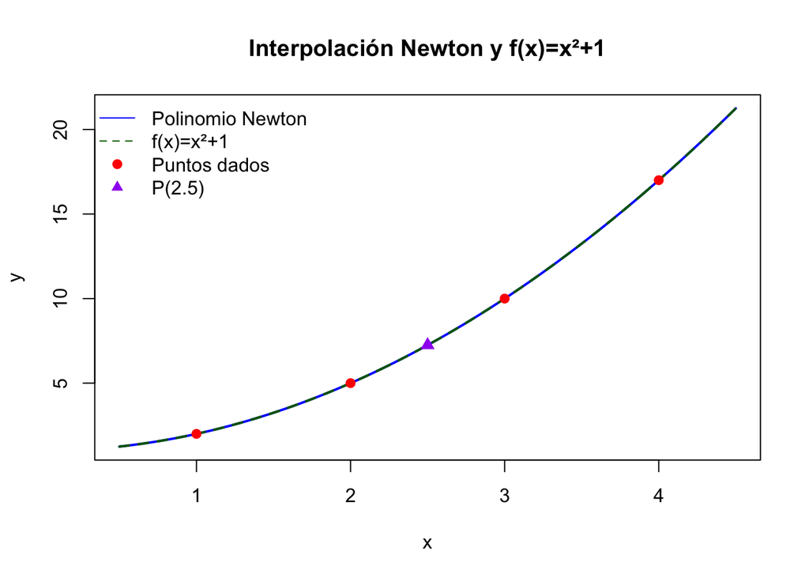

```r
xs_plot <- seq(min(x)-0.5, max(x)+0.5, length.out=300)
ys_poly <- sapply(xs_plot, P_newton_eval)
ys_fx <- xs_plot^2 + 1

plot(xs_plot, ys_poly, type="l", lwd=2, col="blue",
     xlab="x", ylab="y", main="Interpolación Newton y f(x)=x²+1")
lines(xs_plot, ys_fx, lty=2, lwd=2, col="darkgreen")
points(x, y, pch=19, col="red")
points(x_eval, P_at_2_5, pch=17, col="purple", cex=1.2)
legend("topleft",
       legend=c("Polinomio Newton","f(x)=x²+1","Puntos dados","P(2.5)"),
       col=c("blue","darkgreen","red","purple"),
       lty=c(1,2,NA,NA), pch=c(NA,NA,19,17), bty="n")
```

#### **Ejercicio 5.2**

```r
## Datos
x_pts <- c(-1, 0, 2)
y_pts <- c(4, 1, 3)
```

## Construcción simbólica mediante fórmulas de Lagrange (evaluación y expansión)

```r
L0 <- function(xv) { (xv - x_pts[2])*(xv - x_pts[3]) / ((x_pts[1] - x_pts[2])*(x_pts[1] - x_pts[3])) }
L1 <- function(xv) { (xv - x_pts[1])*(xv - x_pts[3]) / ((x_pts[2] - x_pts[1])*(x_pts[2] - x_pts[3])) }
L2 <- function(xv) { (xv - x_pts[1])*(xv - x_pts[2]) / ((x_pts[3] - x_pts[1])*(x_pts[3] - x_pts[2])) }
```

## Polinomio Lagrange como función

```r
P_L <- function(xv) {
  y_pts[1]*L0(xv) + y_pts[2]*L1(xv) + y_pts[3]*L2(xv)
}
```

## Expandir el polinomio numéricamente para obtener coeficientes a0,a1,a2

## Evaluamos en 3 puntos y resolvemos sistema Vandermonde para coeficientes

```r
A <- matrix(c(1, -1, 1^2,    ## x=-1 -> [1, -1, 1]
              1,  0, 0^2,    ## x=0  -> [1,  0, 0]
              1,  2, 2^2),   ## x=2  -> [1,  2, 4]
            nrow=3, byrow=TRUE)
b <- c(P_L(-1), P_L(0), P_L(2))
coef <- solve(A, b)

a0 <- round(as.numeric(coef[1]), 8)
a1 <- round(as.numeric(coef[2]), 8)
a2 <- round(as.numeric(coef[3]), 8)

cat("**Resultado (forma general):**\n\n")
```

```
## **Resultado (forma general):**
```

```r
cat(paste0("Se obtiene el polinomio cuadrático\n\n \\(P_2(x) = ", a0, " + (", a1, ")x + (", a2, ")x^2\\)\n\n"))
```

```
## Se obtiene el polinomio cuadrático
##
##  \(P_2(x) = 1 + (-1.66666667)x + (1.33333333)x^2\)
```

## Mostrar polinomio ordenado (coeficientes agrupados)

```r
cat("**Polinomio simplificado:**\n\n")
```

```
## **Polinomio simplificado:**
```

```r
cat(paste0("$$P_2(x)= ", a2, "x^2 + ", a1, "x + ", a0, "$$\n\n"))
```

```
## $$P_2(x)= 1.33333333x^2 + -1.66666667x + 1$$
```

## Verificación en los puntos dados

```r
vals <- c(P_L(-1), P_L(0), P_L(2))
names(vals) <- c("P(-1)","P(0)","P(2)")
cat("**Verificación en los puntos dados:**\n\n")
```

```
## **Verificación en los puntos dados:**
```

```r
for (i in 1:3) {
  cat(names(vals)[i], " = ", round(vals[i],8), "\n\n")
}
```

```
## P(-1)  =  4
##
## P(0)  =  1
##
## P(2)  =  3
```

## Comprobación simbólica rápida (también mostrar coincidencia con y_pts)

```r
cat("Comprobación comparando con los valores originales:\n\n")
```

```
## Comprobación comparando con los valores originales:
```

```r
comp <- c(round(vals[1],8)==y_pts[1], round(vals[2],8)==y_pts[2], round(vals[3],8)==y_pts[3])
print(data.frame(Punto = c("(-1,4)","(0,1)","(2,3)"),
                 Valor_Interpolado = round(vals,8),
                 Valor_Original = y_pts,
                 Coincide = comp))
```

```
##        Punto Valor_Interpolado Valor_Original Coincide
## P(-1) (-1,4)                 4              4     TRUE
## P(0)   (0,1)                 1              1     TRUE
## P(2)   (2,3)                 3              3     TRUE
```

## Gráfica (polinomio y puntos)

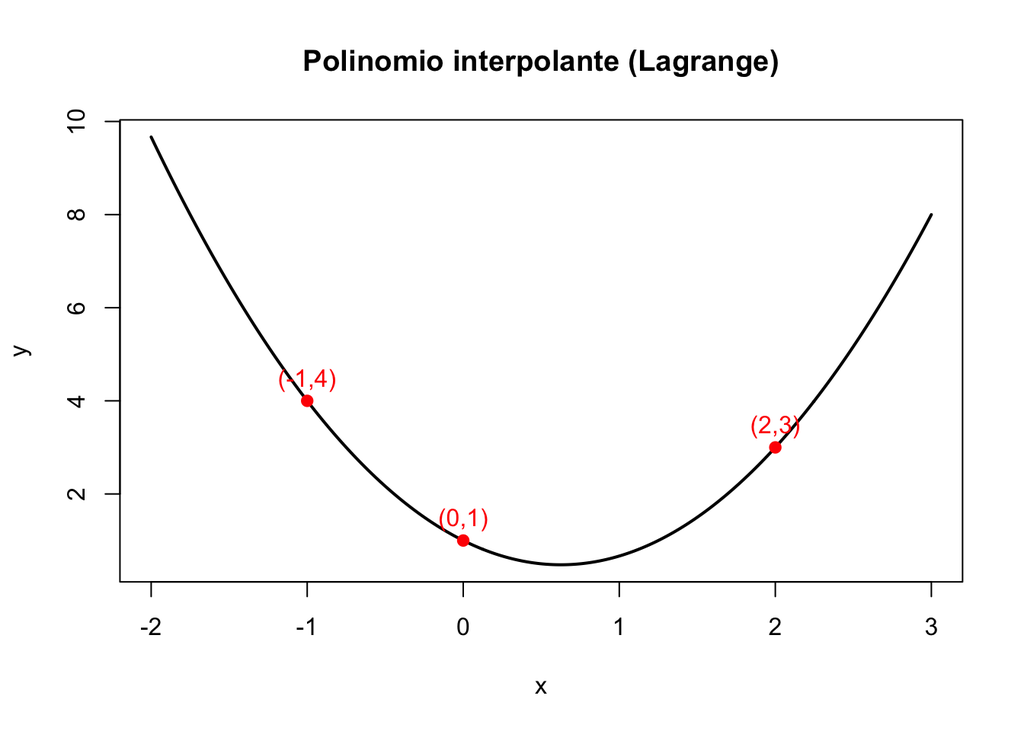

```r
xs <- seq(min(x_pts)-1, max(x_pts)+1, length.out=300)
ys <- sapply(xs, P_L)
plot(xs, ys, type="l", lwd=2, xlab="x", ylab="y", main="Polinomio interpolante (Lagrange)")
points(x_pts, y_pts, pch=19, col="red")
text(x_pts, y_pts, labels=paste0("(", x_pts, ",", y_pts, ")"), pos=3, col="red")
```

# Newton diferencias progresivas

## Ejercicio 6

## Tabla de diferencias progresivas

```r
forward_diffs <- function(x, y) {
  n <- length(y)
  diffs <- list(y)
  for (k in 1:(n - 1)) {
    prev <- diffs[[k]]
    diffs[[k + 1]] <- diff(prev)
  }
  ## Crear data.frame para mostrar
  df <- data.frame(x = x)
  for (k in 1:length(diffs)) {
    col <- c(rep(NA, k - 1), diffs[[k]])
    df[[paste0("Δ", k - 1)]] <- col
  }
  return(list(diffs = diffs, table = df))
}
```

## Tabla de diferencias regresivas

```r
backward_diffs <- function(x, y) {
  n <- length(y)
  diffs <- list(y)
  for (k in 1:(n - 1)) {
    prev <- diffs[[k]]
    diffs[[k + 1]] <- diff(prev)
  }
  df <- data.frame(x = x)
  for (k in 1:length(diffs)) {
    col <- c(diffs[[k]], rep(NA, k - 1))
    df[[paste0("∇", k - 1)]] <- col
  }
  return(list(diffs = diffs, table = df))
}

## Factorial
fact <- function(n) if (n <= 1) 1 else prod(1:n)
```

## Newton hacia adelante

```r
newton_forward_eval <- function(x_nodes, y_nodes, x_eval) {
  h <- x_nodes[2] - x_nodes[1]
  diffs_list <- forward_diffs(x_nodes, y_nodes)$diffs
  a <- sapply(diffs_list, function(v) v[1])
  s <- (x_eval - x_nodes[1]) / h
  p <- a[1]
  for (k in 2:length(a)) {
    term <- a[k]
    num <- 1
    for (j in 0:(k - 2)) num <- num * (s - j)
    p <- p + term * num / fact(k - 1)
  }
  return(p)
}
```

```r
## Newton hacia atrás
newton_backward_eval <- function(x_nodes, y_nodes, x_eval) {
  h <- x_nodes[2] - x_nodes[1]
  diffs_list <- forward_diffs(x_nodes, y_nodes)$diffs
  n <- length(y_nodes)
  a <- sapply(diffs_list, function(v) v[length(v)])
  s <- (x_eval - x_nodes[n]) / h
  p <- a[1]
  for (k in 2:length(a)) {
    term <- a[k]
    num <- 1
    for (j in 0:(k - 2)) num <- num * (s + j)
    p <- p + term * num / fact(k - 1)
  }
  return(p)
}
```

#### Datos:

x = 0, 1, 2, 3, 4  
f(x) = 1, 2, 4, 8, 16

###### a) Tabla de diferencias progresivas

```r
x1 <- 0:4
y1 <- c(1, 2, 4, 8, 16)
res1 <- forward_diffs(x1, y1)
print("Tabla de diferencias progresivas (Δyi):")
```

```
## [1] "Tabla de diferencias progresivas (Δyi):"
```

```r
print(res1$table)
```

```
##   x Δ0 Δ1 Δ2 Δ3 Δ4
## 1 0  1 NA NA NA NA
## 2 1  2  1 NA NA NA
## 3 2  4  2  1 NA NA
## 4 3  8  4  2  1 NA
## 5 4 16  8  4  2  1
```

###### b) Polinomio interpolante con Newton hacia adelante

```r
coefs1 <- sapply(res1$diffs, function(v) v[1])
print("Coeficientes del polinomio de Newton hacia adelante:")
```

```
## [1] "Coeficientes del polinomio de Newton hacia adelante:"
```

```r
print(coefs1)
```

```
## [1] 1 1 1 1 1
```

```r
h1 <- x1[2] - x1[1]
print("Forma general del polinomio:")
```

```
## [1] "Forma general del polinomio:"
```

```r
print(paste0(
  "P(x) = ", coefs1[1],
  " + ", coefs1[2], "·s",
  " + ", coefs1[3], "·s(s−1)/2!",
  " + ", coefs1[4], "·s(s−1)(s−2)/3!",
  " + ", coefs1[5], "·s(s−1)(s−2)(s−3)/4!"
))
```

```
## [1] "P(x) = 1 + 1·s + 1·s(s−1)/2! + 1·s(s−1)(s−2)/3! + 1·s(s−1)(s−2)(s−3)/4!"
```

```r
print(paste("donde s = (x −", x1[1], ")/", h1))
```

```
## [1] "donde s = (x − 0 )/ 1"
```

###### c) Calcule f(2.5) y compare con 2^2.5

```r
x_eval1 <- 2.5
p1_25 <- newton_forward_eval(x1, y1, x_eval1)
real_25 <- 2^(2.5)
print(paste("f(2.5) interpolado =", round(p1_25, 4)))
```

```
## [1] "f(2.5) interpolado = 5.6484"
```

```r
print(paste("2^2.5 =", round(real_25, 4)))
```

```
## [1] "2^2.5 = 5.6569"
```

```r
print(paste("Error =", round(abs(p1_25 - real_25), 6)))
```

```
## [1] "Error = 0.008417"
```

#### Datos:

x = 1, 2, 3, 4  
f(x) = 1, 8, 27, 64

###### a) Tabla de diferencias regresivas

```r
x2 <- 1:4
y2 <- c(1, 8, 27, 64)
res2 <- backward_diffs(x2, y2)
print("Tabla de diferencias regresivas (∇yi):")
```

```
## [1] "Tabla de diferencias regresivas (∇yi):"
```

```r
print(res2$table)
```

```
##   x ∇0 ∇1 ∇2 ∇3
## 1 1  1  7 12  6
## 2 2  8 19 18 NA
## 3 3 27 37 NA NA
## 4 4 64 NA NA NA
```

###### b) Aplique Newton hacia atrás para estimar f(3.4)

```r
x_eval2 <- 3.4
p2_34 <- newton_backward_eval(x2, y2, x_eval2)
real_34 <- (x_eval2)^3
print(paste("f(3.4) interpolado =", round(p2_34, 4)))
```

```
## [1] "f(3.4) interpolado = 39.304"
```

```r
print(paste("Valor exacto =", round(real_34, 4)))
```

```
## [1] "Valor exacto = 39.304"
```

```r
print(paste("Error =", round(abs(p2_34 - real_34), 6)))
```

```
## [1] "Error = 0"
```

#### Datos experimentales

x = 10, 20, 30, 40, 50  
y = 20.5, 24.0, 32.0, 42.5, 51.0

###### a) Verifique que los nodos sean equiespaciados

```r
x3 <- seq(10, 50, by = 10)
y3 <- c(20.5, 24.0, 32.0, 42.5, 51.0)
espacios <- diff(x3)
print("Diferencias entre nodos (deben ser iguales):")
```

```
## [1] "Diferencias entre nodos (deben ser iguales):"
```

```r
print(espacios)
```

```
## [1] 10 10 10 10
```

###### b) Calcule las diferencias progresivas hasta el tercer orden

```r
res3 <- forward_diffs(x3, y3)
print("Tabla de diferencias progresivas (hasta tercer orden):")
```

```
## [1] "Tabla de diferencias progresivas (hasta tercer orden):"
```

```r
print(res3$table)
```

```
##    x   Δ0   Δ1   Δ2   Δ3   Δ4
## 1 10 20.5   NA   NA   NA   NA
## 2 20 24.0  3.5   NA   NA   NA
## 3 30 32.0  8.0  4.5   NA   NA
## 4 40 42.5 10.5  2.5 -2.0   NA
## 5 50 51.0  8.5 -2.0 -4.5 -2.5
```

###### c) Estime y(25) usando Newton hacia adelante

```r
x_eval3 <- 25
p3_25 <- newton_forward_eval(x3, y3, x_eval3)
print(paste("Estimación de y(25) =", round(p3_25, 4)))
```

```
## [1] "Estimación de y(25) = 27.5039"
```

###### d) Comentario sobre estabilidad numérica

```r
print("Comentario:")
```

```
## [1] "Comentario:"
```

```r
print("Usar un polinomio de orden más alto no siempre mejora la precisión.
En datos experimentales, puede generar oscilaciones (fenómeno de Runge),
por lo que un polinomio de orden moderado ofrece mejor estabilidad numérica.")
```

```
## [1] "Usar un polinomio de orden más alto no siempre mejora la precisión.\nEn datos experimentales, puede generar oscilaciones (fenómeno de Runge),\npor lo que un polinomio de orden moderado ofrece mejor estabilidad numérica."
```

## Ejercicio 7

## Tabla de diferencias hacia adelante

```r
forward_diff_table <- function(x, y) {
  n <- length(y)
  diffs <- list(y)
  for (k in 1:(n - 1)) {
    diffs[[k + 1]] <- diff(diffs[[k]])
  }
  df <- data.frame(x = x)
  for (k in 1:length(diffs)) {
    col <- c(rep(NA, k - 1), diffs[[k]])
    df[[paste0("Δ", k - 1)]] <- col
  }
  return(list(diffs = diffs, table = df))
}

## Tabla de diferencias hacia atrás
backward_diff_table <- function(x, y) {
  n <- length(y)
  diffs <- list(y)
  for (k in 1:(n - 1)) {
    diffs[[k + 1]] <- diff(diffs[[k]])
  }
  df <- data.frame(x = x)
  for (k in 1:length(diffs)) {
    col <- c(diffs[[k]], rep(NA, k - 1))
    df[[paste0("∇", k - 1)]] <- col
  }
  return(list(diffs = diffs, table = df))
}

## Factorial
fact <- function(n) if (n <= 1) 1 else prod(1:n)

## Interpolación Newton equiespaciada automática
newton_interp_equispaced <- function(x_nodes, y_nodes, x_eval) {
  h <- x_nodes[2] - x_nodes[1]
  n <- length(x_nodes)

  ## Decidir si usar hacia adelante o hacia atrás
  if (x_eval <= mean(x_nodes)) {
    method <- "adelante"
    diffs <- forward_diff_table(x_nodes, y_nodes)$diffs
    a <- sapply(diffs, function(v) v[1])
    s <- (x_eval - x_nodes[1]) / h
    p <- a[1]
    for (k in 2:length(a)) {
      term <- a[k]
      num <- 1
      for (j in 0:(k - 2)) num <- num * (s - j)
      p <- p + term * num / fact(k - 1)
    }
    ## error de truncamiento (estimado con último término)
    error <- abs(a[length(a)] * s * prod(s - (0:(length(a) - 2))) / fact(length(a) - 1))
  } else {
    method <- "atrás"
    diffs <- backward_diff_table(x_nodes, y_nodes)$diffs
    a <- sapply(diffs, function(v) v[length(v)])
    s <- (x_eval - x_nodes[n]) / h
    p <- a[1]
    for (k in 2:length(a)) {
      term <- a[k]
      num <- 1
      for (j in 0:(k - 2)) num <- num * (s + j)
      p <- p + term * num / fact(k - 1)
    }
    error <- abs(a[length(a)] * s * prod(s + (0:(length(a) - 2))) / fact(length(a) - 1))
  }

  return(list(valor = p, metodo = method, error = error))
}

## Interpolación de Lagrange clásica
lagrange_interp <- function(x, y, x_eval) {
  n <- length(x)
  P <- 0
  for (i in 1:n) {
    L <- 1
    for (j in 1:n) {
      if (j != i) L <- L * (x_eval - x[j]) / (x[i] - x[j])
    }
    P <- P + y[i] * L
  }
  return(P)
}

## Interpolación de Newton (diferencias divididas)
newton_divididas <- function(x, y, x_eval) {
  n <- length(x)
  ## Tabla de diferencias divididas
  dd <- matrix(0, n, n)
  dd[,1] <- y
  for (j in 2:n) {
    for (i in 1:(n - j + 1)) {
      dd[i, j] <- (dd[i + 1, j - 1] - dd[i, j - 1]) / (x[i + j - 1] - x[i])
    }
  }
  ## Evaluación
  P <- dd[1, 1]
  for (j in 2:n) {
    term <- dd[1, j]
    for (k in 1:(j - 1)) term <- term * (x_eval - x[k])
    P <- P + term
  }
  return(list(valor = P, tabla = dd))
}
```

#### Replicar ejemplos anteriores

```r
## Datos del ejercicio anterior (x = 0:4, f = 1,2,4,8,16)
x1 <- 0:4
y1 <- c(1, 2, 4, 8, 16)

## Tabla de diferencias
tabla1 <- forward_diff_table(x1, y1)
print("Tabla de diferencias progresivas:")
```

```
## [1] "Tabla de diferencias progresivas:"
```

```r
print(tabla1$table)
```

```
##   x Δ0 Δ1 Δ2 Δ3 Δ4
## 1 0  1 NA NA NA NA
## 2 1  2  1 NA NA NA
## 3 2  4  2  1 NA NA
## 4 3  8  4  2  1 NA
## 5 4 16  8  4  2  1
```

```r
## Valor estimado f(2.5)
res1 <- newton_interp_equispaced(x1, y1, 2.5)
print(paste("Valor estimado f(2.5) =", round(res1$valor, 4)))
```

```
## [1] "Valor estimado f(2.5) = 5.6484"
```

```r
print(paste("Método usado:", res1$metodo))
```

```
## [1] "Método usado: atrás"
```

```r
print(paste("Error de truncamiento estimado:", round(res1$error, 6)))
```

```
## [1] "Error de truncamiento estimado: 0.035156"
```

```r
## Comparación con valor real 2^2.5
real_25 <- 2^(2.5)
print(paste("Valor real =", round(real_25, 4)))
```

```
## [1] "Valor real = 5.6569"
```

```r
print(paste("Error total =", round(abs(res1$valor - real_25), 6)))
```

```
## [1] "Error total = 0.008417"
```

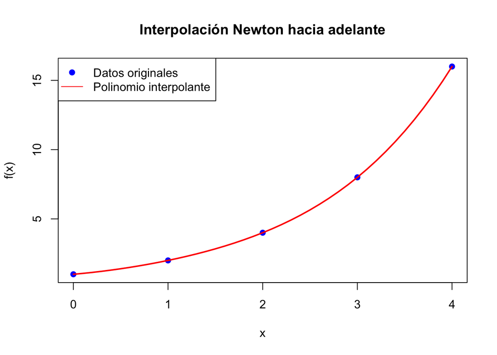

```r
## Gráfica
## Gráfica sin error (corregida)
plot(x1, y1, pch = 19, col = "blue", main = "Interpolación Newton hacia adelante",
     xlab = "x", ylab = "f(x)")

## Función auxiliar para evaluar la interpolación punto a punto
interp_fun <- function(xx) newton_interp_equispaced(x1, y1, xx)$valor

## Secuencia de puntos para trazar la curva
x_seq <- seq(min(x1), max(x1), 0.1)
y_seq <- sapply(x_seq, interp_fun)

## Dibujar el polinomio interpolante
lines(x_seq, y_seq, col = "red", lwd = 2)

legend("topleft", legend = c("Datos originales", "Polinomio interpolante"),
       col = c("blue", "red"), pch = c(19, NA), lty = c(NA, 1))
```

#### Comparación de métodos (Lagrange, Newton, Diferencias finitas)

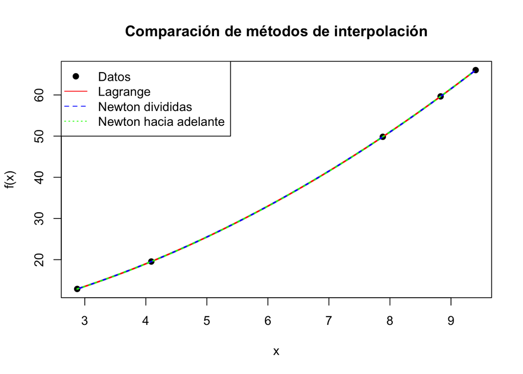

```r
set.seed(123)
x2 <- sort(runif(5, 0, 10))
y2 <- 3 + 2 * x2 + 0.5 * x2^2  ## función cuadrática
x_plot <- seq(min(x2), max(x2), 0.1)

## Lagrange
y_lag <- sapply(x_plot, function(x) lagrange_interp(x2, y2, x))

## Newton divididas
y_new <- sapply(x_plot, function(x) newton_divididas(x2, y2, x)$valor)

## Newton hacia adelante (equiespaciado usando x equidistantes)
x_eq <- seq(min(x2), max(x2), length.out = 5)
y_eq <- 3 + 2 * x_eq + 0.5 * x_eq^2
y_forw <- sapply(x_plot, function(x) newton_interp_equispaced(x_eq, y_eq, x)$valor)

## Gráfica comparativa
plot(x2, y2, pch = 19, col = "black", xlab = "x", ylab = "f(x)",
     main = "Comparación de métodos de interpolación")
lines(x_plot, y_lag, col = "red", lwd = 2)
lines(x_plot, y_new, col = "blue", lwd = 2, lty = 2)
lines(x_plot, y_forw, col = "green", lwd = 2, lty = 3)
legend("topleft", legend = c("Datos", "Lagrange", "Newton divididas", "Newton hacia adelante"),
       col = c("black", "red", "blue", "green"), lty = c(NA, 1, 2, 3), pch = c(19, NA, NA, NA))
```

#### Evaluar con datos dados

x = [0,1,2,3,4],  
y = [2.0, 2.7, 4.8, 8.9, 16.0]

```r
## Ejercicio 7 - Punto 3
x3 <- c(0, 1, 2, 3, 4)
y3 <- c(2.0, 2.7, 4.8, 8.9, 16.0)

## Evaluaciones automáticas
x_eval <- c(1.5, 2.5, 3.5)
resultados <- lapply(x_eval, function(xx) newton_interp_equispaced(x3, y3, xx))
valores_est <- sapply(resultados, function(r) r$valor)

## Reporte de resultados
print(data.frame(x_eval, f_estimado = valores_est))
```

```
##   x_eval f_estimado
## 1    1.5   3.546875
## 2    2.5   6.546875
## 3    3.5  11.996875
```

```r
## Comparación con función de referencia f(x) = 2^x
f_ref <- 2^x_eval
print(data.frame(x_eval, f_estimado = valores_est, f_real = f_ref,
                 error = f_ref - valores_est))
```

```
##   x_eval f_estimado    f_real      error
## 1    1.5   3.546875  2.828427 -0.7184479
## 2    2.5   6.546875  5.656854 -0.8900208
## 3    3.5  11.996875 11.313708 -0.6831665
```

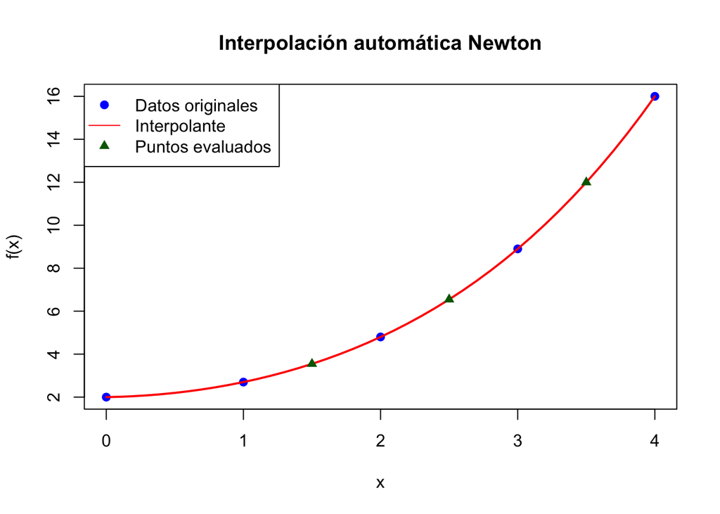

```r
## Gráfica (corregida)
plot(x3, y3, pch = 19, col = "blue", main = "Interpolación automática Newton",
     xlab = "x", ylab = "f(x)")

## Evaluar punto a punto (evita error)
interp_fun <- function(xx) newton_interp_equispaced(x3, y3, xx)$valor
x_seq <- seq(min(x3), max(x3), 0.1)
y_seq <- sapply(x_seq, interp_fun)

lines(x_seq, y_seq, col = "red", lwd = 2)
points(x_eval, valores_est, col = "darkgreen", pch = 17)

legend("topleft",
       legend = c("Datos originales", "Interpolante", "Puntos evaluados"),
       col = c("blue", "red", "darkgreen"), pch = c(19, NA, 17), lty = c(NA, 1, NA))
```

#### Ejercicio 8

```r
## Datos
x8 <- c(0, 1, 2)
y8 <- c(1, 3, 11)

## Sistema para P2(x) = a0 + a1*x + a2*x^2
A8 <- matrix(c(1, 0, 0,
               1, 1, 1,
               1, 2, 4), ncol = 3, byrow = TRUE)
coef8 <- solve(A8, y8)

print("Coeficientes del polinomio (a0, a1, a2):")
```

```
## [1] "Coeficientes del polinomio (a0, a1, a2):"
```

```r
print(coef8)
```

```
## [1]  1 -1  3
```

```r
## Polinomio
P8 <- function(x) coef8[1] + coef8[2]*x + coef8[3]*x^2

## Evaluación
x_eval8 <- 1.5
y_eval8 <- P8(x_eval8)
print(paste("P2(1.5) =", y_eval8))
```

```
## [1] "P2(1.5) = 6.25"
```

```r
## Comparación con el valor esperado (6.25)
print(paste("Error absoluto =", abs(y_eval8 - 6.25)))
```

```
## [1] "Error absoluto = 0"
```

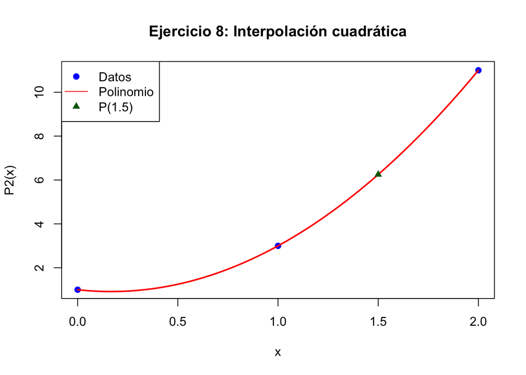

```r
## Gráfica
plot(x8, y8, pch = 19, col = "blue", main = "Ejercicio 8: Interpolación cuadrática",
     xlab = "x", ylab = "P2(x)")
curve(P8(x), add = TRUE, col = "red", lwd = 2)
points(x_eval8, y_eval8, col = "darkgreen", pch = 17)
legend("topleft", legend = c("Datos", "Polinomio", "P(1.5)"),
       col = c("blue", "red", "darkgreen"), pch = c(19, NA, 17), lty = c(NA, 1, NA))
```

## Ejercicio 9

```r
x9 <- c(1, 2, 3, 4)
y9 <- c(2, 5, 10, 17)
```

## Diferencias

```r
dy1 <- diff(y9)
dy2 <- diff(dy1)
dy3 <- diff(dy2)

print("Diferencias de primer orden:")
```

```
## [1] "Diferencias de primer orden:"
```

```r
print(dy1)
```

```
## [1] 3 5 7
```

```r
print("Diferencias de segundo orden:")
```

```
## [1] "Diferencias de segundo orden:"
```

```r
print(dy2)
```

```
## [1] 2 2
```

```r
print("Diferencias de tercer orden:")
```

```
## [1] "Diferencias de tercer orden:"
```

```r
print(dy3)
```

```
## [1] 0
```

## Polinomio P(x) = x^2 + 1 (verificado)

```r
P9 <- function(x) x^2 + 1
```

## Evaluación

```r
x_eval9 <- 2.5
y_eval9 <- P9(x_eval9)
print(paste("P(2.5) =", y_eval9))
```

```
## [1] "P(2.5) = 7.25"
```

## Gráfica

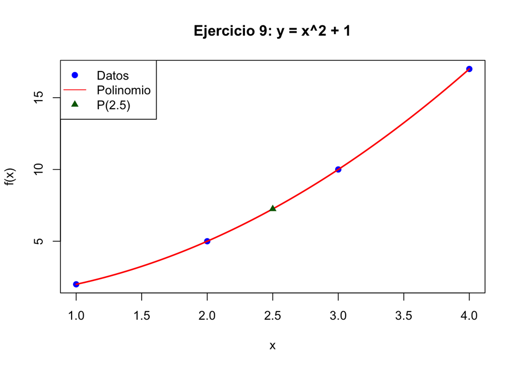

```r
plot(x9, y9, pch = 19, col = "blue", main = "Ejercicio 9: y = x^2 + 1",
     xlab = "x", ylab = "f(x)")
curve(P9(x), add = TRUE, col = "red", lwd = 2)
points(x_eval9, y_eval9, col = "darkgreen", pch = 17)
legend("topleft", legend = c("Datos", "Polinomio", "P(2.5)"),
       col = c("blue", "red", "darkgreen"), pch = c(19, NA, 17), lty = c(NA, 1, NA))
```

```r
knitr::opts_chunk$set(echo = TRUE)
```

## Datos

```r
x10 <- c(-1, 0, 2)
y10 <- c(4, 1, 3)
```

## Sistema para P2(x) = a0 + a1*x + a2*x^2

```r
A10 <- matrix(c(1, -1, 1,
1, 0, 0,
1, 2, 4), ncol = 3, byrow = TRUE)
coef10 <- solve(A10, y10)

print("Coeficientes del polinomio (a0, a1, a2):")
```

```
## [1] "Coeficientes del polinomio (a0, a1, a2):"
```

```r
print(coef10)
```

```
## [1]  1.000000 -1.666667  1.333333
```

## Polinomio

```r
P10 <- function(x) coef10[1] + coef10[2]*x + coef10[3]*x^2
```

## Verificación de puntos

```r
print("Verificación de P2(x) en los nodos originales:")
```

```
## [1] "Verificación de P2(x) en los nodos originales:"
```

```r
for (xi in x10) {
print(paste("x =", xi, "→ P2(x) =", P10(xi)))
}
```

```
## [1] "x = -1 → P2(x) = 4"
## [1] "x = 0 → P2(x) = 1"
## [1] "x = 2 → P2(x) = 3"
```

## Gráfica

[figure not shown]

```r
plot(x10, y10, pch = 19, col = "blue", main = "Ejercicio 10: Interpolación cuadrática",
xlab = "x", ylab = "P2(x)")
curve(P10(x), add = TRUE, col = "red", lwd = 2)
legend("topleft", legend = c("Datos", "Polinomio interpolante"),
col = c("blue", "red"), pch = c(19, NA), lty = c(NA, 1))
```

## Ejercicio 11

# Datos: x = 0,1,2,3,4 ; y = {1,2,4,8,16}

```r
x11 <- 0:4
y11 <- c(1,2,4,8,16)
print(data.frame(x = x11, y = y11))
```

```
##   x  y
## 1 0  1
## 2 1  2
## 3 2  4
## 4 3  8
## 5 4 16
```

# Tabla de diferencias progresivas

```r
dy11_1 <- diff(y11)
dy11_2 <- diff(dy11_1)
dy11_3 <- diff(dy11_2)
dy11_4 <- diff(dy11_3)
print(paste("Δy0 =", dy11_1[1]))
```

```
## [1] "Δy0 = 1"
```

```r
print(paste("Δ²y0 =", dy11_2[1]))
```

```
## [1] "Δ²y0 = 1"
```

```r
print(paste("Δ³y0 =", dy11_3[1]))
```

```
## [1] "Δ³y0 = 1"
```

```r
print(paste("Δ⁴y0 =", dy11_4[1]))
```

```
## [1] "Δ⁴y0 = 1"
```

# Interpolación Newton hacia adelante (grado 4) en x0=0, h=1, p = (2.5−0)/1 = 2.5

```r
p <- 2.5
y0 <- y11[1]
term1 <- p * dy11_1[1]
term2 <- p * (p - 1) / 2 * dy11_2[1]
term3 <- p * (p - 1) * (p - 2) / 6 * dy11_3[1]
term4 <- p * (p - 1) * (p - 2) * (p - 3) / 24 * dy11_4[1]
P11 <- y0 + term1 + term2 + term3 + term4
print(paste("P(2.5) =", P11))
```

```
## [1] "P(2.5) = 5.6484375"
```

# Comparación con 2^2.5

```r
true11 <- 2^2.5
print(paste("2^2.5 =", true11))
```

```
## [1] "2^2.5 = 5.65685424949238"
```

```r
print(paste("Error ≈", P11 - true11))
```

```
## [1] "Error ≈ -0.00841674949238058"
```

## Ejercicio 12

# Datos: x = 1,2,3,4 ; f(x) = x^3 = {1,8,27,64}

```r
x12 <- c(1,2,3,4)
y12 <- c(1,8,27,64)
print(data.frame(x = x12, y = y12))
```

```
##   x  y
## 1 1  1
## 2 2  8
## 3 3 27
## 4 4 64
```